# Lab 5: Moderation

SEM in R with lavaan

Kyle M. Lang

Updated: 2026-03-12

In this lab, you will practice moderation analysis using path analysis and SEM in [**lavaan**](https://cran.r-project.org/web/packages/lavaan/). You will work with both continuous and categorical moderators.

# 1 Continuous Moderators

## 1.1 Data

We will first analyze a synthetic version of the [*Outlook on Life Survey*](https://doi.org/10.3886/ICPSR35348.v1) data. The original data were collected in the United States in 2012 to measure, among other things, attitudes about racial issues, opinions of the Federal government, and beliefs about the future.

We will work with a synthesized subset of the original data. You can access these synthetic data as [*outlook.rds*](https://github.com/kylelang/lavaan-e-learning/raw/main/5_moderation/data/outlook.rds). This dataset comprises 2288 observations of the following 13 variables.

- `d1:d3`: Three observed indicators of a construct measuring disillusionment with the US Federal government.
  - Higher scores indicate more disillusionment $\\[6pt]$
- `s1:s4`: Four observed indicators of a construct measuring the perceived achievability of material success.
  - Higher scores indicate greater perceived achievability $\\[6pt]$
- `progress`: A single item assessing perceived progress toward achieving the “American Dream”
  - Higher scores indicate greater perceived progress $\\[6pt]$
- `merit`: A single item assessing endorsement of the meritocratic ideal that hard work leads to success.
  - Higher scores indicate stronger endorsement of the meritocratic ideal $\\[6pt]$
- `lib2Con`: A single item assessing liberal-to-conservative orientation
  - Lower scores are more liberal, higher scores are more conservative $\\[6pt]$
- `party`: A four-level factor indicating self-reported political party affiliation $\\[6pt]$
- `disillusion`: A scale score representing disillusionment with the US Federal government
  - Created as the mean of `d1:d3` $\\[6pt]$
- `success`: A scale score representing the perceived achievability of material success
  - Created as the mean of `s1:s4`

To satisfy the [access and licensing](https://www.icpsr.umich.edu/web/pages/datamanagement/lifecycle/access.html) conditions under which the original data are distributed, the data contained in *outlook.rds* were synthesized from the original variables using the methods described by [Volker and Vink (2021)](https://doi.org/10.3390/psych3040045). You can access the original data [here](https://doi.org/10.3886/ICPSR35348.v1), and you can access the code used to process the data [here](https://github.com/kylelang/lavaan-e-learning/blob/main/code/lab_prep/process_outlook_data.R).

### 1.1.1

**Read in the *outlook.rds* dataset.**

```r
dataDir <- "data"
outlook <- readRDS(here::here(dataDir, "outlook.rds"))
```

NOTE: In the following, I will refer to these data as the *outlook data*.

### 1.1.2

**Summarize the outlook data to get a sense of their characteristics.**

```r
head(outlook)
```

|  | d1 | d2 | d3 | s1 | s2 | s3 | s4 | progress | merit | lib2Con | party | disillusion | success |
| --- | --- | --- | --- | --- | --- | --- | --- | --- | --- | --- | --- | --- | --- |
| 1 | 4 | 4 | 4 | 3 | 2 | 3 | 3 | 8 | 6 | 5 | republican | 4.000000 | 2.75 |
| 2 | 4 | 2 | 4 | 3 | 2 | 2 | 3 | 4 | 5 | 6 | independent | 3.333333 | 2.50 |
| 3 | 4 | 4 | 4 | 4 | 2 | 4 | 3 | 6 | 5 | 4 | independent | 4.000000 | 3.25 |
| 4 | 5 | 4 | 5 | 2 | 1 | 1 | 1 | 1 | 4 | 1 | democrat | 4.666667 | 1.25 |
| 5 | 5 | 3 | 4 | 2 | 1 | 2 | 2 | 6 | 3 | 4 | democrat | 4.000000 | 1.75 |
| 6 | 4 | 5 | 4 | 2 | 2 | 1 | 3 | 5 | 4 | 4 | democrat | 4.333333 | 2.00 |

```r
summary(outlook)
```

```
       d1              d2              d3              s1
 Min.   :1.000   Min.   :1.000   Min.   :1.000   Min.   :1.000
 1st Qu.:3.000   1st Qu.:2.000   1st Qu.:3.000   1st Qu.:2.000
 Median :4.000   Median :3.000   Median :4.000   Median :2.000
 Mean   :3.642   Mean   :3.218   Mean   :3.629   Mean   :2.288
 3rd Qu.:4.000   3rd Qu.:4.000   3rd Qu.:4.000   3rd Qu.:3.000
 Max.   :5.000   Max.   :5.000   Max.   :5.000   Max.   :4.000
       s2              s3              s4           progress
 Min.   :1.000   Min.   :1.000   Min.   :1.000   Min.   : 1.000
 1st Qu.:1.000   1st Qu.:1.000   1st Qu.:2.000   1st Qu.: 5.000
 Median :2.000   Median :2.000   Median :2.000   Median : 7.000
 Mean   :1.922   Mean   :2.012   Mean   :2.469   Mean   : 6.432
 3rd Qu.:2.000   3rd Qu.:3.000   3rd Qu.:3.000   3rd Qu.: 8.000
 Max.   :4.000   Max.   :4.000   Max.   :4.000   Max.   :10.000
     merit          lib2Con              party       disillusion
 Min.   :1.000   Min.   :1.000   republican : 332   Min.   :1.000
 1st Qu.:4.000   1st Qu.:3.000   democrat   :1264   1st Qu.:3.000
 Median :5.000   Median :4.000   independent: 576   Median :3.667
 Mean   :4.826   Mean   :3.998   other      : 116   Mean   :3.497
 3rd Qu.:6.000   3rd Qu.:5.000                      3rd Qu.:4.000
 Max.   :7.000   Max.   :7.000                      Max.   :5.000
    success
 Min.   :1.000
 1st Qu.:1.750
 Median :2.000
 Mean   :2.173
 3rd Qu.:2.500
 Max.   :4.000
```

```r
str(outlook)
```

```
'data.frame':   2288 obs. of  13 variables:
 $ d1         : num  4 4 4 5 5 4 5 4 4 4 ...
 $ d2         : num  4 2 4 4 3 5 4 2 4 5 ...
 $ d3         : num  4 4 4 5 4 4 4 3 3 4 ...
 $ s1         : num  3 3 4 2 2 2 2 1 3 3 ...
 $ s2         : num  2 2 2 1 1 2 1 1 2 2 ...
 $ s3         : num  3 2 4 1 2 1 1 1 3 2 ...
 $ s4         : num  3 3 3 1 2 3 3 2 2 2 ...
 $ progress   : num  8 4 6 1 6 5 7 6 9 7 ...
 $ merit      : num  6 5 5 4 3 4 2 5 5 5 ...
 $ lib2Con    : num  5 6 4 1 4 4 4 4 4 5 ...
 $ party      : Factor w/ 4 levels "republican","democrat",..: 1 3 3 2 2 2 2 2 4 1 ...
 $ disillusion: num  4 3.33 4 4.67 4 ...
 $ success    : num  2.75 2.5 3.25 1.25 1.75 2 1.75 1.25 2.5 2.25 ...
```

## 1.2 OLS Regression

We will first consider moderation by a continuous variable. Specifically, we will work with a model encoding the following relations:

- Belief in the achievability of success, *success*, predicts perceived progress toward the American Dream, *progress*, as the focal effect.
- Disillusionment with the US Federal government, *disillusion* moderates the *success* $\rightarrow$ *progress* effect.
- Placement on the liberal-to-conservative continuum, *lib2Con* is partialed out as a covariate.

We will first estimate this model as an OLS regression model.

### 1.2.1

**Draw the conceptual path diagram for the model described above.**

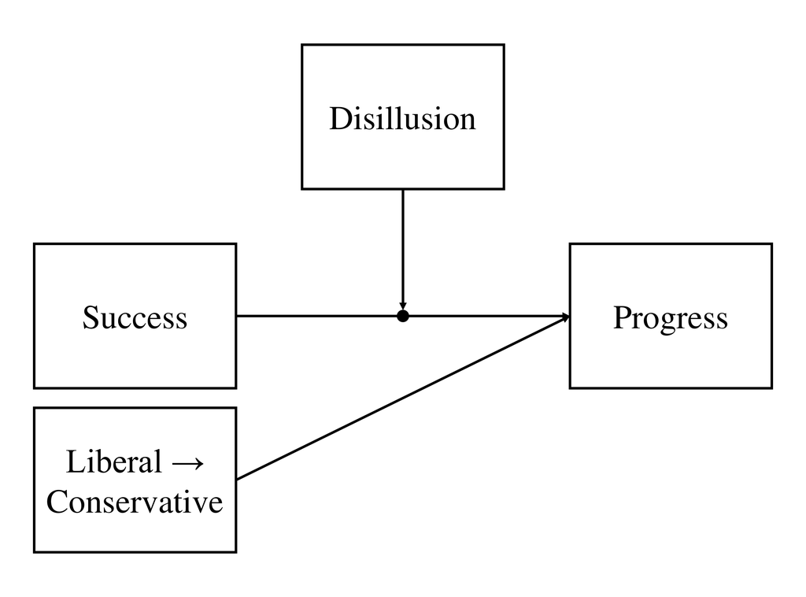

### 1.2.2

**Draw the analytic path diagram for the model described above.**

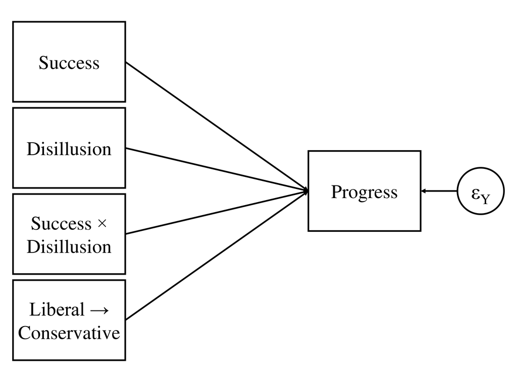

### 1.2.3

**Write out the regression equation necessary to evaluate the moderation hypothesis described above.**

$$Y_{progress} = \beta_0 + \beta_1 W_{lib2Con} + \beta_2 X_{success} + \beta_3 Z_{disillusion} + \beta_4 XZ + \varepsilon$$

### 1.2.4

**Estimate the moderated regression model via OLS regression.**

- Use the `lm()` function to estimate the model.

```r
olsFit <- lm(progress ~ lib2Con + success * disillusion, data = outlook)
```

### 1.2.5

**Summarize the fitted model and interpret the results.**

- Is the moderation hypothesis supported?
- How does disillusionment level affect the focal effect?

```r
summary(olsFit)
```

```
Call:
lm(formula = progress ~ lib2Con + success * disillusion, data = outlook)

Residuals:
    Min      1Q  Median      3Q     Max
-7.4315 -1.2525  0.1307  1.4369  5.6717

Coefficients:
                    Estimate Std. Error t value Pr(>|t|)
(Intercept)          6.81128    0.62073  10.973  < 2e-16 ***
lib2Con              0.03052    0.03040   1.004   0.3155
success              0.42360    0.25853   1.638   0.1015
disillusion         -0.78002    0.16864  -4.625 3.95e-06 ***
success:disillusion  0.17429    0.07273   2.396   0.0166 *
---
Signif. codes:  0 '***' 0.001 '**' 0.01 '*' 0.05 '.' 0.1 ' ' 1

Residual standard error: 2.041 on 2283 degrees of freedom
Multiple R-squared:  0.1385,    Adjusted R-squared:  0.137
F-statistic: 91.74 on 4 and 2283 DF,  p-value: < 2.2e-16
```

Yes, *disillusion* significantly moderates the relation between *success* and *progress* $(\beta = 0.174,$ $t(2283) = 2.396,$ $p = 0.017)$ such that the effect of *success* on *progress* increases as levels of *disillusion* increase, after controlling for *lib2Con*.

The [**rockchalk**](https://cran.r-project.org/web/packages/rockchalk/index.html) package contains some useful routines for probing interactions estimated via `lm()`. Specifically, the `plotslopes()` function will estimate and plot simple slopes, and the `testSlopes()` function tests the simple slopes estimated by `plotSlopes()`.

### 1.2.6

**Probe the interaction.**

- Use the `plotSlopes()` and `testSlopes()` functions from the **rockchalk** package to conduct a simple slopes analysis for the model from 1.2.4.

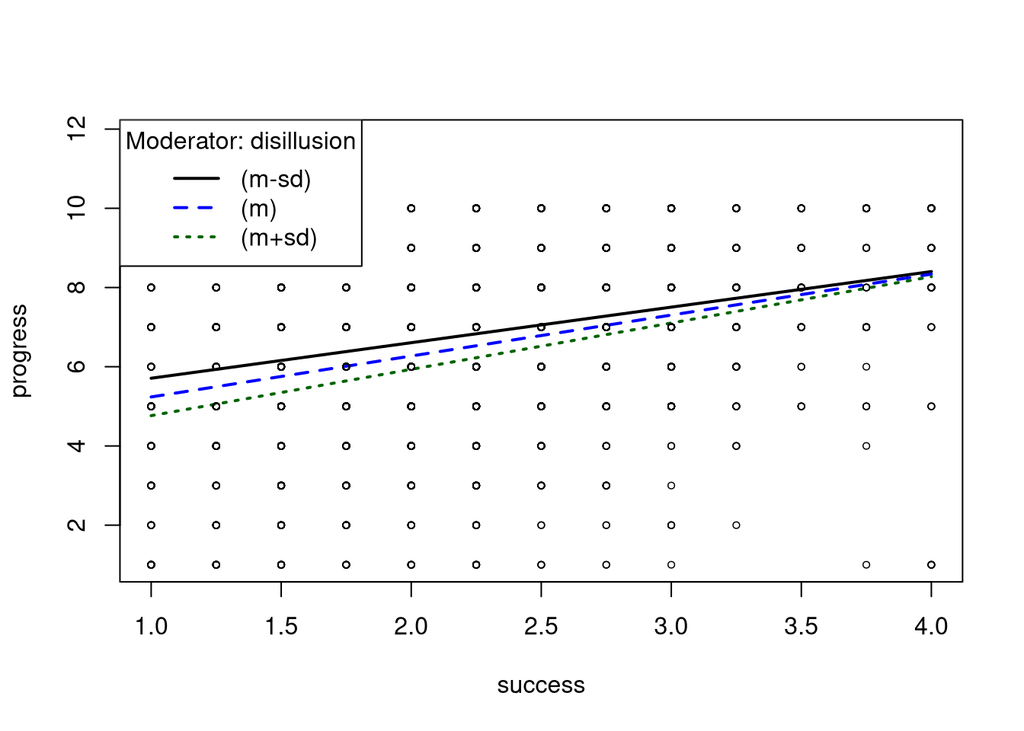

```r
library(rockchalk)

## Estimate and plot simple slopes:
psOut <- plotSlopes(olsFit,
                    plotx    = "success",
                    modx     = "disillusion",
                    modxVals = "std.dev")
```

```r
## Test the simple slopes:
tsOut <- testSlopes(psOut)
```

```
Values of disillusion OUTSIDE this interval:
         lo          hi
-28.9332857   0.2672244
cause the slope of (b1 + b2*disillusion)success to be statistically significant
```

```r
## View the results:
tsOut$hypotests
```

|  | "disillusion" | slope | Std. Error | t value | Pr(>\|t\|) |
| --- | --- | --- | --- | --- | --- |
| (m-sd) | 2.72 | 0.8976759 | 0.08320659 | 10.78852 | 1.678871e-26 |
| (m) | 3.50 | 1.0336252 | 0.06467513 | 15.98180 | 1.397265e-54 |
| (m+sd) | 4.28 | 1.1695744 | 0.08876398 | 13.17623 | 2.888389e-38 |

NOTE: The message printed by `testSlopes()` gives the boundaries of the *Johnson-Neyman Region of Significance* ([Johnson & Neyman, 1936)](http://www.worldcat.org/oclc/29082872). Johnson-Neyman analysis is an alternative method of probing interactions that we have not covered in this course. For more information, check out [Preacher, et al. (2006)](https://doi.org/10.3102%2F10769986031004437).

## 1.3 Path Analysis

We will now use **lavaan** to estimate the moderated regression model from above as a path analysis model.

### 1.3.1

**Define the model syntax for the path analytic version of the model described above.**

- Parameterize the model as in the OLS regression.
- Use only observed items and scale scores. Do not define any latent variables.

```r
pathMod <- '
progress ~ 1 + lib2Con + success + disillusion + success:disillusion
'
```

### 1.3.2

**Estimate the path model on the outlook data.**

```r
library(lavaan)

pathFit <- sem(pathMod, data = outlook)
```

### 1.3.3

**Summarize the fitted path model and interpret the results.**

- Do the results match the OLS regression results?

```r
summary(pathFit)
```

```
lavaan 0.6-21 ended normally after 1 iteration

  Estimator                                         ML
  Optimization method                           NLMINB
  Number of model parameters                         6

  Number of observations                          2288

Model Test User Model:

  Test statistic                                 0.000
  Degrees of freedom                                 0

Parameter Estimates:

  Standard errors                             Standard
  Information                                 Expected
  Information saturated (h1) model          Structured

Regressions:
                   Estimate  Std.Err  z-value  P(>|z|)
  progress ~
    lib2Con           0.031    0.030    1.005    0.315
    success           0.424    0.258    1.640    0.101
    disillusion      -0.780    0.168   -4.630    0.000
    success:dsllsn    0.174    0.073    2.399    0.016

Intercepts:
                   Estimate  Std.Err  z-value  P(>|z|)
   .progress          6.811    0.620   10.985    0.000

Variances:
                   Estimate  Std.Err  z-value  P(>|z|)
   .progress          4.157    0.123   33.823    0.000
```

Yes, the estimates and inferential conclusions are all the same as in the OLS regression model.

The [**semTools**](https://cran.r-project.org/web/packages/semTools/index.html) package contains some helpful routines for probing interactions estimated via the `lavaan()` function (or one of it’s wrappers). Specifically, the `probe2WayMC()` and `plotProbe()` functions will estimate/test simple slopes and plot the estimated simple slopes, respectively.

### 1.3.4

**Probe the interaction from 1.3.2 using *semTools* utilities.**

- Use `probe2WayMC()` to estimate and test the simple slopes and intercepts.
- Use `plotProbe()` to visualize the simple slopes.
- Define the simple slopes with the same conditional values of *disillusion* that you used in 1.2.6.
- Which simple slopes are significant?
- Do these results match the results from 1.2.6?

```r
library(semTools)

## Compute simple slopes and intercepts:
ssOut <- probe2WayMC(pathFit,
                     nameX    = c("success", "disillusion", "success:disillusion"),
                     nameY    = "progress",
                     modVar   = "disillusion",
                     valProbe = outlook |>
                       summarise("m-sd" = mean(disillusion) - sd(disillusion),
                                 mean = mean(disillusion),
                                 "m+sd" = mean(disillusion) + sd(disillusion)
                                 ) |>
                       unlist()
                     )

## Check the results:
ssOut
```

```
$SimpleIntcept
     disillusion   est    se      z pvalue
m-sd       2.719 4.690 0.231 20.271      0
mean       3.497 4.084 0.190 21.508      0
m+sd       4.274 3.477 0.230 15.122      0

$SimpleSlope
     disillusion   est    se      z pvalue
m-sd       2.719 0.897 0.083 10.792      0
mean       3.497 1.033 0.065 15.994      0
m+sd       4.274 1.169 0.088 13.223      0
```

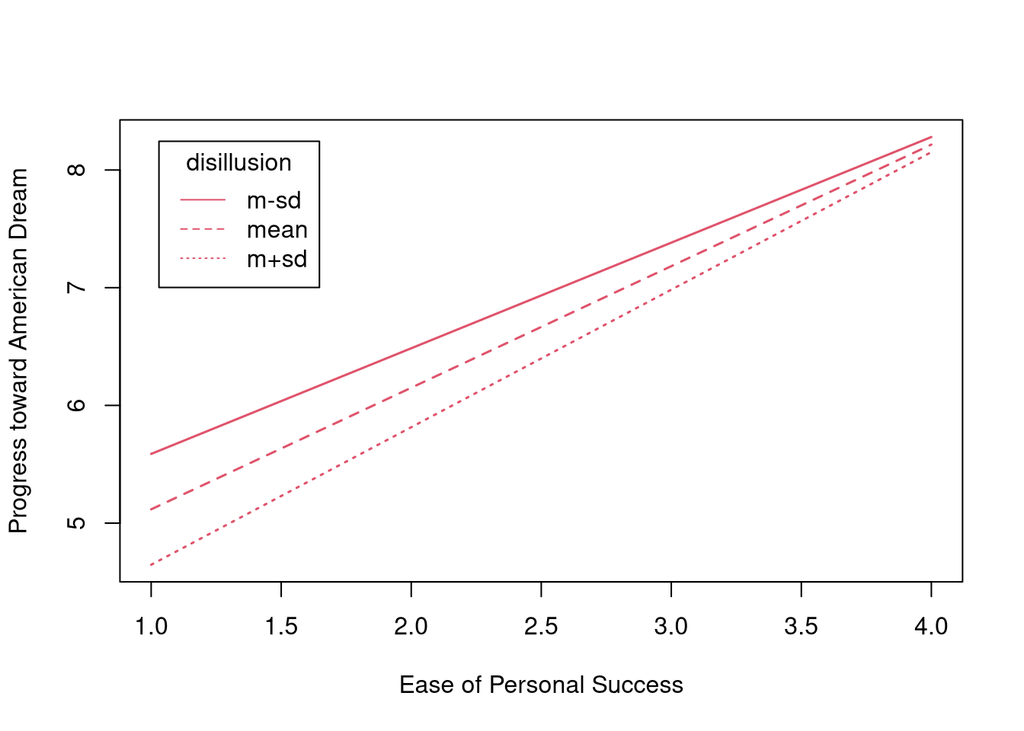

```r
## Visualize the simple slopes:
plotProbe(ssOut,
          xlim = range(outlook$success),
          xlab = "Ease of Personal Success",
          ylab = "Progress toward American Dream",
          legendArgs = list(legend = rownames(ssOut[[1]]))
          )
```

- Each of the simple slopes is significant. As level of disillusionment increases, the effect of *success* on *progress* also increases, and this effect is significant for all levels of *disillusion* considered here.
- Yes, these results match the simple slopes from the OLS regression analysis.

## 1.4 Double Mean Centering

In this section and the next, we will test the above moderation hypothesis using latent variables and interactions therebetween. We will define these interaction factors using products of the observed indicators.

In this section, we will create the interaction factor using the *Double Mean Centering* method.

### 1.4.1

**Define the model syntax for the CFA.**

- Indicated the *success* factor from the four relevant scale items:
  - `s1:s4`
- Indicated the *disillusionment* factor from the three relevant scale items:
  - `d1:d3`
- Do not include the interaction factor.

```r
cfaMod <- '
success     =~ s1 + s2 + s3 + s4
disillusion =~ d1 + d2 + d3
'
```

### 1.4.2

**Estimate the CFA model on the outlook data.**

- Correlate the latent factors.
- Estimate the mean structure.
- Set the scale via the *marker variable method*.

```r
library(dplyr)

## Use a dplyr pipeline to remove scale scores before estimating the CFA:
cfaFit <- outlook |>
  select(-success, -disillusion) |>
  cfa(cfaMod, data = _, meanstructure = TRUE)
```

### 1.4.3

**Summarize the fitted CFA and check the model fit.**

- Do the parameter estimates look sensible?
- Does the model fit the data well enough?

```r
summary(cfaFit)
```

```
lavaan 0.6-21 ended normally after 27 iterations

  Estimator                                         ML
  Optimization method                           NLMINB
  Number of model parameters                        22

  Number of observations                          2288

Model Test User Model:

  Test statistic                                34.227
  Degrees of freedom                                13
  P-value (Chi-square)                           0.001

Parameter Estimates:

  Standard errors                             Standard
  Information                                 Expected
  Information saturated (h1) model          Structured

Latent Variables:
                   Estimate  Std.Err  z-value  P(>|z|)
  success =~
    s1                1.000
    s2                0.964    0.033   28.784    0.000
    s3                0.978    0.034   28.474    0.000
    s4                0.864    0.035   25.022    0.000
  disillusion =~
    d1                1.000
    d2                0.980    0.057   17.219    0.000
    d3                0.671    0.039   17.233    0.000

Covariances:
                   Estimate  Std.Err  z-value  P(>|z|)
  success ~~
    disillusion      -0.122    0.014   -8.814    0.000

Intercepts:
                   Estimate  Std.Err  z-value  P(>|z|)
   .s1                2.288    0.018  123.823    0.000
   .s2                1.922    0.017  112.139    0.000
   .s3                2.012    0.018  113.363    0.000
   .s4                2.469    0.019  133.061    0.000
   .d1                3.642    0.022  166.962    0.000
   .d2                3.218    0.025  130.972    0.000
   .d3                3.629    0.017  218.549    0.000

Variances:
                   Estimate  Std.Err  z-value  P(>|z|)
   .s1                0.382    0.015   24.655    0.000
   .s2                0.302    0.013   23.024    0.000
   .s3                0.339    0.014   23.918    0.000
   .s4                0.489    0.017   28.588    0.000
   .d1                0.582    0.032   18.057    0.000
   .d2                0.894    0.038   23.828    0.000
   .d3                0.403    0.017   23.404    0.000
    success           0.399    0.023   17.530    0.000
    disillusion       0.507    0.039   13.151    0.000
```

```r
fitMeasures(cfaFit)
```

```
                 npar                  fmin                 chisq
               22.000                 0.007                34.227
                   df                pvalue        baseline.chisq
               13.000                 0.001              3676.619
          baseline.df       baseline.pvalue                   cfi
               21.000                 0.000                 0.994
                  tli                  nnfi                   rfi
                0.991                 0.991                 0.985
                  nfi                  pnfi                   ifi
                0.991                 0.613                 0.994
                  rni                  logl     unrestricted.logl
                0.994            -19459.120            -19442.006
                  aic                   bic                ntotal
            38962.239             39088.419              2288.000
                 bic2                 rmsea        rmsea.ci.lower
            39018.521                 0.027                 0.016
       rmsea.ci.upper        rmsea.ci.level          rmsea.pvalue
                0.038                 0.900                 1.000
       rmsea.close.h0 rmsea.notclose.pvalue     rmsea.notclose.h0
                0.050                 0.000                 0.080
                  rmr            rmr_nomean                  srmr
                0.016                 0.018                 0.018
         srmr_bentler   srmr_bentler_nomean                  crmr
                0.018                 0.020                 0.020
          crmr_nomean            srmr_mplus     srmr_mplus_nomean
                0.023                 0.018                 0.020
                cn_05                 cn_01                   gfi
             1495.870              1851.920                 1.000
                 agfi                  pgfi                   mfi
                0.999                 0.371                 0.995
                 ecvi
                0.034
```

This model looks good. All measurement model parameters seem reasonable, and the model fits the data very well.

### 1.4.4

**Compute product indicators for the interaction construct.**

- Use the Double Mean Centering method to create the product indicators.
- Create all possible product terms (i.e., don’t use the matched-pairs approach).

*HINT*: The **semTools**::`indProd()` function can be a huge help here.

```r
outlook2 <- indProd(data      = outlook,
                    var1      = paste0("s", 1:4),
                    var2      = paste0("d", 1:3),
                    match     = FALSE,
                    meanC     = TRUE,
                    doubleMC  = TRUE,
                    residualC = FALSE)
```

### 1.4.5

**Define the model syntax for the structural model.**

- Include the *progress* and *lib2Con* variables as single observed items.
- Estimate the intercept of the latent regression model.
- Don’t forget to include the residual correlations for the product indicators.

```r
## Define only the new syntax pieces:
semMod <- '
## Define the interaction factor:
interact =~ s1.d1 + s1.d2 + s1.d3
interact =~ s2.d1 + s2.d2 + s2.d3
interact =~ s3.d1 + s3.d2 + s3.d3
interact =~ s4.d1 + s4.d2 + s4.d3

## Correlated residuals for product terms involving the same item:
s1.d1 ~~ s1.d2 + s1.d3 + s2.d1 + s3.d1 + s4.d1
s2.d1 ~~ s2.d2 + s2.d3 + s3.d1 + s4.d1
s3.d1 ~~ s3.d2 + s3.d3 + s4.d1
s4.d1 ~~ s4.d2 + s4.d3

s1.d2 ~~ s1.d3 + s2.d2 + s3.d2 + s4.d2
s2.d2 ~~ s2.d3 + s3.d2 + s4.d2
s3.d2 ~~ s3.d3 + s4.d2
s4.d2 ~~ s4.d3

s1.d3 ~~ s2.d3 + s3.d3 + s4.d3
s2.d3 ~~ s3.d3 + s4.d3
s3.d3 ~~ s4.d3

## Define the structural relations:
progress ~ 1 + lib2Con + success + disillusion + interact
'

## Paste the new syntax onto the CFA syntax:
semMod <- paste(cfaMod, semMod, sep = '\n')
```

### 1.4.6

**Estimate the structural model.**

```r
semFit <- outlook2 |>
  select(-success, -disillusion) |>
  sem(semMod, data = _)
```

### 1.4.7

**Summarize and interpret the results.**

- Is the moderation hypothesis supported?
- Do the results differ from the path analysis version?

```r
summary(semFit)
```

```
lavaan 0.6-21 ended normally after 108 iterations

  Estimator                                         ML
  Optimization method                           NLMINB
  Number of model parameters                        96

  Number of observations                          2288

Model Test User Model:

  Test statistic                               272.665
  Degrees of freedom                               154
  P-value (Chi-square)                           0.000

Parameter Estimates:

  Standard errors                             Standard
  Information                                 Expected
  Information saturated (h1) model          Structured

Latent Variables:
                   Estimate  Std.Err  z-value  P(>|z|)
  success =~
    s1                1.000
    s2                0.966    0.033   29.303    0.000
    s3                0.976    0.034   28.877    0.000
    s4                0.861    0.034   25.191    0.000
  disillusion =~
    d1                1.000
    d2                0.997    0.057   17.587    0.000
    d3                0.682    0.039   17.612    0.000
  interact =~
    s1.d1             1.000
    s1.d2             1.114    0.075   14.857    0.000
    s1.d3             0.735    0.050   14.723    0.000
    s2.d1             0.977    0.051   19.220    0.000
    s2.d2             1.102    0.080   13.753    0.000
    s2.d3             0.726    0.053   13.630    0.000
    s3.d1             1.063    0.056   18.835    0.000
    s3.d2             1.112    0.082   13.501    0.000
```

[output cut: 95 more lines]

```
   .s1.d2             0.880    0.033   26.690    0.000
   .s1.d3             0.367    0.014   26.332    0.000
   .s2.d1             0.623    0.023   26.592    0.000
   .s2.d2             0.724    0.028   25.472    0.000
   .s2.d3             0.336    0.013   25.946    0.000
   .s3.d1             0.633    0.025   25.403    0.000
   .s3.d2             0.813    0.031   26.399    0.000
   .s3.d3             0.369    0.014   26.273    0.000
   .s4.d1             0.756    0.026   29.213    0.000
   .s4.d2             0.926    0.031   29.532    0.000
   .s4.d3             0.455    0.015   29.587    0.000
   .progress          3.975    0.124   32.016    0.000
    success           0.399    0.023   17.681    0.000
    disillusion       0.496    0.037   13.249    0.000
    interact          0.246    0.026    9.616    0.000
```

- Yes, the moderation hypothesis is supported. The level of *disillusion* significantly affects the *success* to *progress* effect $(\beta = 0.303,$ $z = 2.71,$ $p = 0.007).$
- The inference is the same as in the path analysis, but the moderation effect is more significant (i.e., has a smaller p-value) here.
  - Note that we cannot directly compare the effect sizes since the variables have different scales in the two models.

### 1.4.8

**Probe the interaction.**

- Use `probe2WayMC()` to estimate and test the simple slopes.
- Use `plotProbe()` to visualize the simple slopes.

```r
ssOut <- probe2WayMC(semFit,
                     nameX    = c("success", "disillusion", "interact"),
                     nameY    = "progress",
                     modVar   = "disillusion",
                     valProbe = c(-1, 0, 1)
                     )

ssOut
```

```
$SimpleIntcept
  disillusion   est    se      z pvalue
1          -1 6.792 0.152 44.596      0
2           0 6.297 0.129 48.833      0
3           1 5.802 0.152 38.091      0

$SimpleSlope
  disillusion   est    se      z pvalue
1          -1 0.914 0.132  6.902      0
2           0 1.217 0.086 14.204      0
3           1 1.519 0.149 10.199      0
```

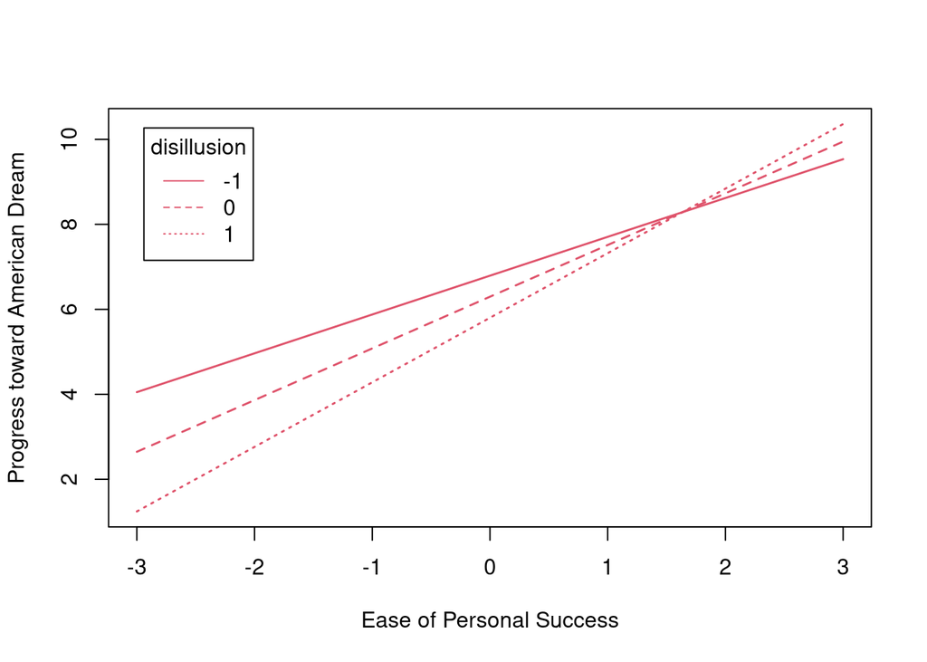

```r
plotProbe(ssOut,
          xlim = c(-3, 3),
          xlab = "Ease of Personal Success",
          ylab = "Progress toward American Dream")
```

## 1.5 Residual Centering

Now, we will conduct the same analysis using the *Residual Centering* approach to define the interaction factor.

### 1.5.1

**Compute product indicators for the interaction construct.**

- Use the Residual Centering method (a.k.a., Orthogonalization) to create the product indicators.
- Create all possible product terms (i.e., don’t use the matched-pairs approach).

```r
outlook2 <- indProd(data      = outlook,
                    var1      = paste0("s", 1:4),
                    var2      = paste0("d", 1:3),
                    match     = FALSE,
                    meanC     = FALSE,
                    doubleMC  = FALSE,
                    residualC = TRUE)
```

### 1.5.2

**Define the model syntax for the structural model.**

- Include the *progress* and *lib2Con* variables as single observed items.
- Estimate the intercept of the latent regression model.

```r
## We only need to add commands to fix the covariance between the interaction
## factor and its constituent factors.
semMod <- paste(semMod,
                'success     ~~ 0 * interact',
                'disillusion ~~ 0 * interact',
                sep = '\n')
```

### 1.5.3

**Estimate the structural model.**

```r
semFit <- outlook2 |>
  select(-success, -disillusion) |>
  sem(semMod, data = _)
```

### 1.5.4

**Summarize and interpret the results.**

- Is the moderation hypothesis supported?
- Do the results differ from the double mean centered version?

```r
summary(semFit)
```

```
lavaan 0.6-21 ended normally after 107 iterations

  Estimator                                         ML
  Optimization method                           NLMINB
  Number of model parameters                        94

  Number of observations                          2288

Model Test User Model:

  Test statistic                               139.562
  Degrees of freedom                               156
  P-value (Chi-square)                           0.823

Parameter Estimates:

  Standard errors                             Standard
  Information                                 Expected
  Information saturated (h1) model          Structured

Latent Variables:
                   Estimate  Std.Err  z-value  P(>|z|)
  success =~
    s1                1.000
    s2                0.964    0.033   29.282    0.000
    s3                0.974    0.034   28.850    0.000
    s4                0.861    0.034   25.221    0.000
  disillusion =~
    d1                1.000
    d2                0.997    0.057   17.584    0.000
    d3                0.684    0.039   17.611    0.000
  interact =~
    s1.d1             1.000
    s1.d2             1.128    0.076   14.801    0.000
    s1.d3             0.741    0.051   14.651    0.000
    s2.d1             0.966    0.051   18.985    0.000
    s2.d2             1.104    0.081   13.641    0.000
    s2.d3             0.731    0.054   13.550    0.000
    s3.d1             1.048    0.056   18.641    0.000
    s3.d2             1.108    0.083   13.387    0.000
```

[output cut: 96 more lines]

```
   .s1.d2             0.873    0.033   26.389    0.000
   .s1.d3             0.364    0.014   26.078    0.000
   .s2.d1             0.625    0.023   26.856    0.000
   .s2.d2             0.721    0.028   25.355    0.000
   .s2.d3             0.334    0.013   25.748    0.000
   .s3.d1             0.634    0.025   25.720    0.000
   .s3.d2             0.807    0.031   26.358    0.000
   .s3.d3             0.368    0.014   26.280    0.000
   .s4.d1             0.754    0.026   29.328    0.000
   .s4.d2             0.919    0.031   29.259    0.000
   .s4.d3             0.451    0.015   29.325    0.000
   .progress          3.980    0.124   32.093    0.000
    success           0.400    0.023   17.697    0.000
    disillusion       0.495    0.037   13.240    0.000
    interact          0.243    0.025    9.556    0.000
```

- Yes, the moderation hypothesis is supported. The level of *disillusion* significantly affects the *success* to *progress* effect $(\beta = 0.264,$ $z = 2.38,$ $p = 0.017).$
- The inference is the same as in the double mean centered version, but the moderation effect is slightly smaller and less significant (i.e., has a larger p-value) here.

When we define the interaction construct using residual centering, we can use the `probe2WayRC()` function from **semTools** to conduct the simple slopes analysis. As before, we can subsequently visualize the simple slopes using the `plotProbe()` function.

### 1.5.5

**Probe the interaction.**

- Use `probe2WayRC()` to estimate and test simple slopes and intercepts.
- Use `plotProbe()` to visualize the simple slopes.

```r
ssOut <- probe2WayRC(semFit,
                     nameX    = c("success", "disillusion", "interact"),
                     nameY    = "progress",
                     modVar   = "disillusion",
                     valProbe = c(-1, 0, 1)
                     )

ssOut
```

```
$SimpleIntcept
  disillusion   est    se      z pvalue
1          -1 6.822 0.156 43.719      0
2           0 6.329 0.133 47.460      0
3           1 5.835 0.156 37.397      0

$SimpleSlope
  disillusion   est    se      z pvalue
1          -1 0.927 0.146  6.363      0
2           0 1.191 0.085 14.064      0
3           1 1.455 0.146  9.989      0
```

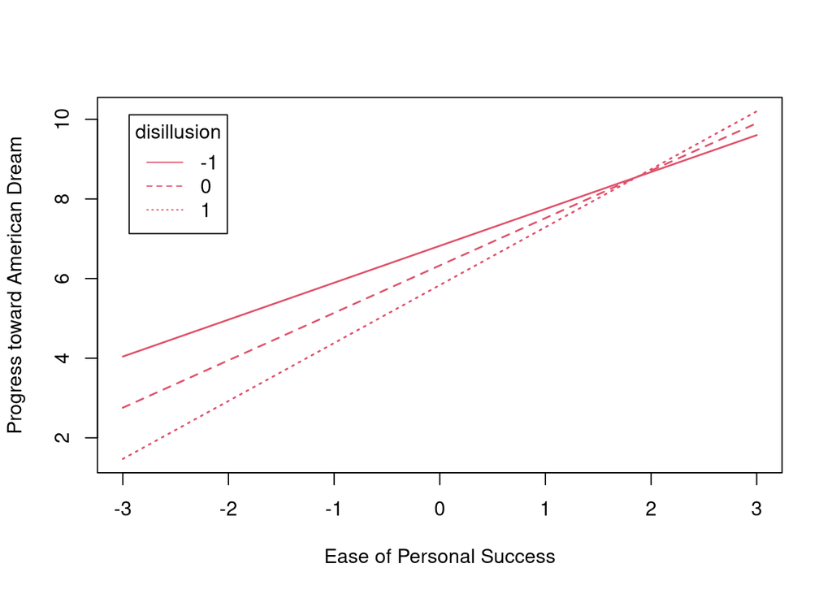

```r
plotProbe(ssOut,
          xlim = c(-3, 3),
          xlab = "Ease of Personal Success",
          ylab = "Progress toward American Dream")
```

In the next section, we will conduct the same analysis using the *Structural after Measurement* (SAM) approach to define the latent variable interaction.

## 1.6 Structural after Measurement

In March 2026, the SAM implementation in **lavaan** is still limited, but it now has sufficient functionality for testing moderation with latent variable interactions. Crucially, we can use bootstrapping to estimate standard errors, so we can now conduct significance tests for the latent variable interaction terms. Analytic, two-step standard errors for latent variable interactions are not yet available.

### 1.6.1

**Define the model syntax for the structural model.**

- Include the *progress* and *lib2Con* variables as single observed items.
- Estimate the intercept of the latent regression model.

```r
## We only need to add a line to specify the latent regression equation.
samMod <- '
## Define the structural relations:
progress ~ 1 + lib2Con + success + disillusion + success:disillusion
'

## Combine the latent regression equation with the syntax for the CFA:
samMod <- paste(cfaMod, samMod, sep = '\n')
```

### 1.6.2

**Estimate the structural model.**

1. Estimate the model without bootstrapping to check the model specification
   - Set `se = "none"`
2. Estimate the model again, and use bootstrapping to estimate the standard errors.
   - Set `se = "bootstrap"`

```r
# Estimate the model without standard errors
samFit <- outlook |>
  select(-success, -disillusion) |>
  sam(samMod, data = _, se = "none")

# Check the results
summary(samFit)
```

```
  SAM method                                     LOCAL
  Mapping matrix M method                           ML
  Number of measurement blocks                       2
  Estimator measurement part                        ML
  Estimator  structural part                        ML

  Number of observations                          2288

Summary Information Measurement + Structural:

  Block      Latent Nind Chisq Df
      1 disillusion    3 0.000  0
      2     success    4 2.775  2

  Model-based reliability latent variables:

  success disillusion progress lib2Con
    0.801       0.665        1       1

  Summary Information Structural part:

  chisq df cfi rmsea srmr
      0  0   1     0    0

Parameter Estimates:


Regressions:
                   Estimate
  progress ~
    lib2Con           0.047
    success           1.208
    disillusion      -0.489
    success:dsllsn    0.268

Covariances:
                   Estimate
  success ~~
    disillusion      -0.123
    success:dsllsn   -0.037
  disillusion ~~
    success:dsllsn    0.016

Intercepts:
                   Estimate
   .progress          6.277
    success:dsllsn   -0.123

Variances:
                   Estimate
   .progress          3.977
    success           0.406
    disillusion       0.512
    success:dsllsn    0.309
```

```r
# Estimate the model with bootstrapped standard errors
samFit <- outlook |>
  select(-success, -disillusion) |>
  sam(samMod, data = _, se = "bootstrap")
```

### 1.6.3

**Summarize and interpret the results.**

- Is the moderation hypothesis supported?
- Do the results differ from the two product indicator versions?

```r
summary(samFit, ci = TRUE)
```

```
  SAM method                                     LOCAL
  Mapping matrix M method                           ML
  Number of measurement blocks                       2
  Estimator measurement part                        ML
  Estimator  structural part                        ML

  Number of observations                          2288

Summary Information Measurement + Structural:

  Block      Latent Nind Chisq Df
      1 disillusion    3 0.000  0
      2     success    4 2.775  2

  Model-based reliability latent variables:

  success disillusion progress lib2Con
    0.801       0.665        1       1

  Summary Information Structural part:

  chisq df cfi rmsea srmr
      0  0   1     0    0

Parameter Estimates:

  Standard errors                            Bootstrap
  Number of requested bootstrap draws             1000
  Number of successful bootstrap draws            1000

Regressions:
                   Estimate  Std.Err  z-value  P(>|z|) ci.lower ci.upper
  progress ~
    lib2Con           0.047    0.031    1.536    0.125   -0.014    0.109
    success           1.208    0.092   13.106    0.000    1.028    1.393
    disillusion      -0.489    0.085   -5.766    0.000   -0.667   -0.334
    success:dsllsn    0.268    0.106    2.519    0.012    0.056    0.477

Covariances:
                   Estimate  Std.Err  z-value  P(>|z|) ci.lower ci.upper
  success ~~
    disillusion      -0.123    0.015   -8.300    0.000   -0.152   -0.093
    success:dsllsn   -0.037    0.016   -2.381    0.017   -0.069   -0.007
  disillusion ~~
    success:dsllsn    0.016    0.021    0.788    0.431   -0.025    0.060

Intercepts:
                   Estimate  Std.Err  z-value  P(>|z|) ci.lower ci.upper
   .progress          6.277    0.126   49.672    0.000    6.036    6.529
    success:dsllsn   -0.123    0.015   -8.300    0.000   -0.152   -0.093

Variances:
                   Estimate  Std.Err  z-value  P(>|z|) ci.lower ci.upper
   .progress          3.977    0.134   29.598    0.000    3.713    4.214
    success           0.406    0.022   18.729    0.000    0.364    0.448
    disillusion       0.512    0.041   12.394    0.000    0.431    0.598
    success:dsllsn    0.309    0.037    8.408    0.000    0.241    0.387
```

- Yes, the moderation hypothesis is supported. The level of *disillusion* significantly affects the *success* to *progress* effect $(\beta = 0.268,$ $95\% \mathit{CI} = [0.056; 0.477]).$
- The inference is the same as in the product indicator approaches. The size of the moderation effect is nearly identical to the estimate from the residual centering method.

When we define the interaction term using SAM, we can use the `simple_slopes()` function from **modsem** to conduct a simple slopes analysis, and we can use the `modsem::plot_interaction()` function to visualize the simple slopes.

### 1.6.4

**Probe the interaction.**

- Use `modsem::simple_slopes()` to estimate and test simple slopes.
- Use `modsem::plot_interaction()` to visualize the simple slopes.

```r
library(modsem)

# Test simple slopes:
simple_slopes(model = samFit,
              y = "progress",
              x = "success",
              z = "disillusion",
              vals_z = c(-1, 0, 1),
              rescale = TRUE)
```

*NOTE:* When we specify `rescale = TRUE`, the `simple_slopes()` function interprets the values we specify for `vals_z` on a standardized scale. So, specifying `vals_z = c(-1, 0, 1)` is equivalent to requesting the simple slopes at one SD below the mean of Z, the mean of Z, and one SD above the mean of Z.

```
Difference test of progress~success|disillusion at disillusion = -0.716 and 0.716:
┌───────────┬───────────┬─────────┬─────────┬────────────────┐
│Difference │ Std.Error │ z.value │ p.value │  Conf.Interval │
╞═══════════╪═══════════╪═════════╪═════════╪════════════════╡
│      0.38 │      0.15 │    2.52 │   0.012 │  [0.085, 0.68] │
└───────────┴───────────┴─────────┴─────────┴────────────────┘

Effect of progress~success|disillusion given values of disillusion:
┌─────────────────┬─────────────┬───────────┬─────────┬─────────┬───────────────┐
│progress~success │ disillusion │ Std.Error │ z.value │ p.value │ Conf.Interval │
╞═════════════════╪═════════════╪═══════════╪═════════╪═════════╪═══════════════╡
│            1.02 │       -0.72 │     0.102 │    9.93 │   0.000 │  [0.82, 1.22] │
│            1.21 │        0.00 │     0.092 │   13.11 │   0.000 │  [1.03, 1.39] │
│            1.40 │        0.72 │     0.134 │   10.41 │   0.000 │  [1.14, 1.66] │
└─────────────────┴─────────────┴───────────┴─────────┴─────────┴───────────────┘


Predicted progress, given disillusion = -0.72:
┌────────┬────────────────────┬───────────┬─────────┬─────────┬───────────────┐
│success │ Predicted progress │ Std.Error │ z.value │ p.value │ Conf.Interval │
╞════════╪════════════════════╪═══════════╪═════════╪═════════╪═══════════════╡
│  -1.91 │               4.68 │      0.25 │   -6.49 │   0.000 │  [4.20, 5.17] │
│  -1.27 │               5.33 │      0.19 │   -4.92 │   0.000 │  [4.96, 5.71] │
│  -0.64 │               5.98 │      0.15 │   -2.01 │   0.045 │  [5.69, 6.27] │
│   0.00 │               6.63 │      0.12 │    2.81 │   0.005 │  [6.38, 6.87] │
│   0.64 │               7.27 │      0.13 │    7.51 │   0.000 │  [7.01, 7.53] │
│   1.27 │               7.92 │      0.17 │    9.78 │   0.000 │  [7.59, 8.25] │
│   1.91 │               8.57 │      0.22 │   10.53 │   0.000 │  [8.14, 9.00] │
└────────┴────────────────────┴───────────┴─────────┴─────────┴───────────────┘


Predicted progress, given disillusion = 0:
┌────────┬────────────────────┬───────────┬─────────┬─────────┬───────────────┐
│success │ Predicted progress │ Std.Error │ z.value │ p.value │ Conf.Interval │
╞════════╪════════════════════╪═══════════╪═════════╪═════════╪═══════════════╡
│  -1.91 │               3.97 │      0.20 │  -11.32 │   0.000 │  [3.57, 4.37] │
│  -1.27 │               4.74 │      0.16 │   -9.52 │   0.000 │  [4.42, 5.05] │
│  -0.64 │               5.51 │      0.13 │   -5.80 │   0.000 │  [5.25, 5.77] │
│   0.00 │               6.28 │      0.13 │    0.00 │   1.000 │  [6.03, 6.52] │
│   0.64 │               7.05 │      0.15 │    5.28 │   0.000 │  [6.76, 7.33] │
│   1.27 │               7.82 │      0.18 │    8.42 │   0.000 │  [7.46, 8.17] │
│   1.91 │               8.58 │      0.23 │   10.08 │   0.000 │  [8.14, 9.03] │
└────────┴────────────────────┴───────────┴─────────┴─────────┴───────────────┘


Predicted progress, given disillusion = 0.72:
┌────────┬────────────────────┬───────────┬─────────┬─────────┬───────────────┐
│success │ Predicted progress │ Std.Error │ z.value │ p.value │ Conf.Interval │
╞════════╪════════════════════╪═══════════╪═════════╪═════════╪═══════════════╡
│  -1.91 │               3.25 │      0.28 │  -10.94 │   0.000 │  [2.71, 3.79] │
│  -1.27 │               4.14 │      0.21 │  -10.14 │   0.000 │  [3.73, 4.56] │
│  -0.64 │               5.04 │      0.16 │   -7.60 │   0.000 │  [4.72, 5.36] │
│   0.00 │               5.93 │      0.15 │   -2.27 │   0.023 │  [5.62, 6.23] │
│   0.64 │               6.82 │      0.19 │    2.87 │   0.004 │  [6.45, 7.19] │
│   1.27 │               7.71 │      0.25 │    5.76 │   0.000 │  [7.22, 8.20] │
│   1.91 │               8.60 │      0.32 │    7.24 │   0.000 │  [7.97, 9.23] │
└────────┴────────────────────┴───────────┴─────────┴─────────┴───────────────┘
```

We are primarily interested in the contents of the second table: those are the significance tests for our three simple slopes. In this case, we see that the focal effect (`success` $\rightarrow$ `progress`) is statistically significant at one SD below the mean of `disillusion`, at the mean of `disillusion`, and at one SD above the mean of `disillusion`.

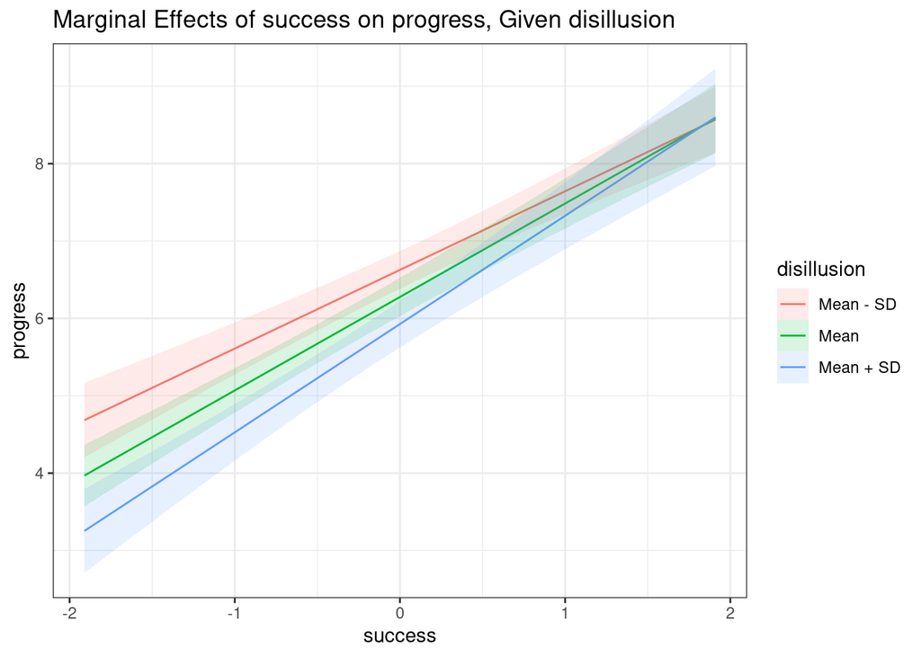

```r
library(ggplot2) # for scale_XX_discrete() functions

# Define some pretty labels
zLabels <- c("Mean - SD", "Mean", "Mean + SD")

# Generate a simple slopes plot:
plot_interaction(model = samFit,
                 y = "progress",
                 x = "success",
                 z = "disillusion",
                 vals_z = c(-1, 0, 1),
                 rescale = TRUE) +
  scale_color_discrete(labels = zLabels) +
  scale_fill_discrete(labels = zLabels)
```

## 1.7 Latent Moderated Structural Equations

Finally, we will use the *latent moderated structural equations* (LMS) approach to estimate the latent variable interaction terms. We need to use the **modsem** package for this analysis because **lavaan** does not implement the LMS approach.

### 1.7.1

**Define the model syntax for the structural model.**

- Include the *progress* and *lib2Con* variables as single observed items.
- Estimate the intercept of the latent regression model.

This is a bit of a trick question, the model syntax is exactly the same as it was in the SAM analysis. We can simply re-use our SAM model syntax for the LMS model.

### 1.7.2

**Estimate the structural model.**

- Use the `modsem::modsem()` function to estimate your model.
- Specify the estimation method via the `method` argument.

```r
# Estimate the model without standard errors
lmsFit <- outlook |>
  select(-success, -disillusion) |>
  modsem(samMod, data = _, method = "lms")
```

### 1.7.3

**Summarize and interpret the results.**

- Is the moderation hypothesis supported?
- Do the results differ from the other approaches you’ve tried?

```r
summary(lmsFit)
```

```
modsem (1.0.17) ended normally after 28 iterations

  Estimator                                        LMS
  Optimization method                       EMA-NLMINB
  Number of model parameters                        32

  Number of observations                          2288

Loglikelihood and Information Criteria:
  Loglikelihood                              -28352.14
  Akaike (AIC)                                56768.28
  Bayesian (BIC)                              56951.81

Numerical Integration:
  Points of integration (per dim)                   24
  Dimensions                                         1
  Total points of integration                       24

Fit Measures for Baseline Model (H0):
                                              Standard
  Chi-square                                     58.62
  Degrees of Freedom (Chi-square)                   23
  P-value (Chi-square)                           0.000
  RMSEA                                          0.026

  Loglikelihood                              -28357.17
  Akaike (AIC)                                56776.35
  Bayesian (BIC)                              56954.15

Comparative Fit to H0 (LRT test):
  Loglikelihood change                            5.03
  Difference test (D)                            10.07
  Degrees of freedom (D)                             1
  P-value (D)                                    0.002

R-Squared Interaction Model (H1):
  progress                                       0.185
R-Squared Baseline Model (H0):
  progress                                       0.171
R-Squared Change (H1 - H0):
```

[output cut: 45 more lines]

```
    lib2Con         0.149      0.026    5.638    0.000

Variances:
                 Estimate  Std.Error  z.value  P(>|z|)
   .s1              0.381      0.015   24.929    0.000
   .s2              0.300      0.013   23.390    0.000
   .s3              0.341      0.014   24.526    0.000
   .s4              0.491      0.017   28.822    0.000
   .d1              0.587      0.031   18.951    0.000
   .d2              0.900      0.037   24.514    0.000
   .d3              0.399      0.017   23.478    0.000
    success         0.400      0.023   17.567    0.000
    disillusin      0.502      0.037   13.437    0.000
    lib2Con         1.996      0.059   33.822    0.000
   .progress        3.953      0.124   31.782    0.000
```

- Yes, the moderation hypothesis is supported. The level of *disillusion* significantly affects the *success* to *progress* effect $(\beta = 0.355,$ $z = 3.157,$ $p = 0.002).$
- The inference is the same as all previous approaches. The moderation effect is larger and more significant than the effects produced by all other approaches.

When we estimate our moderated model using using `modsem()`, we can use the `simple_slopes()` function from **modsem** to conduct a simple slopes analysis, and we can use the `modsem::plot_interaction()` function to visualize the simple slopes.

### 1.7.4

**Probe the interaction.**

- Use `modsem::simple_slopes()` to estimate and test simple slopes.
- Use `modsem::plot_interaction()` to visualize the simple slopes.

```r
library(modsem)
library(ggplot2)

# Test simple slopes:
simple_slopes(model = lmsFit,
              y = "progress",
              x = "success",
              z = "disillusion",
              vals_z = c(-1, 0, 1),
              rescale = TRUE)
```

```
Difference test of progress~success|disillusion at disillusion = -0.708 and 0.708:
┌───────────┬───────────┬─────────┬─────────┬───────────────┐
│Difference │ Std.Error │ z.value │ p.value │ Conf.Interval │
╞═══════════╪═══════════╪═════════╪═════════╪═══════════════╡
│      0.50 │      0.16 │    3.16 │   0.002 │  [0.19, 0.82] │
└───────────┴───────────┴─────────┴─────────┴───────────────┘

Effect of progress~success|disillusion given values of disillusion:
┌─────────────────┬─────────────┬───────────┬─────────┬─────────┬───────────────┐
│progress~success │ disillusion │ Std.Error │ z.value │ p.value │ Conf.Interval │
╞═════════════════╪═════════════╪═══════════╪═════════╪═════════╪═══════════════╡
│            0.97 │       -0.71 │     0.109 │    8.89 │   0.000 │  [0.76, 1.18] │
│            1.22 │        0.00 │     0.085 │   14.28 │   0.000 │  [1.05, 1.39] │
│            1.47 │        0.71 │     0.124 │   11.85 │   0.000 │  [1.23, 1.71] │
└─────────────────┴─────────────┴───────────┴─────────┴─────────┴───────────────┘


Predicted progress, given disillusion = -0.71:
┌────────┬────────────────────┬───────────┬─────────┬─────────┬───────────────┐
│success │ Predicted progress │ Std.Error │ z.value │ p.value │ Conf.Interval │
╞════════╪════════════════════╪═══════════╪═════════╪═════════╪═══════════════╡
│  -1.90 │               4.81 │      0.27 │   -5.58 │   0.000 │  [4.29, 5.33] │
│  -1.27 │               5.42 │      0.21 │   -4.16 │   0.000 │  [5.02, 5.83] │
│  -0.63 │               6.04 │      0.16 │   -1.58 │   0.114 │  [5.72, 6.35] │
│   0.00 │               6.65 │      0.13 │    2.65 │   0.008 │  [6.39, 6.91] │
│   0.63 │               7.26 │      0.14 │    6.90 │   0.000 │  [6.99, 7.54] │
│   1.27 │               7.87 │      0.18 │    9.01 │   0.000 │  [7.53, 8.22] │
│   1.90 │               8.49 │      0.23 │    9.68 │   0.000 │  [8.04, 8.93] │
└────────┴────────────────────┴───────────┴─────────┴─────────┴───────────────┘


Predicted progress, given disillusion = 0:
┌────────┬────────────────────┬───────────┬─────────┬─────────┬───────────────┐
│success │ Predicted progress │ Std.Error │ z.value │ p.value │ Conf.Interval │
╞════════╪════════════════════╪═══════════╪═════════╪═════════╪═══════════════╡
│  -1.90 │               3.98 │      0.21 │  -11.27 │   0.000 │  [3.57, 4.38] │
│  -1.27 │               4.75 │      0.17 │   -9.21 │   0.000 │  [4.42, 5.08] │
│  -0.63 │               5.52 │      0.14 │   -5.48 │   0.000 │  [5.24, 5.80] │
│   0.00 │               6.29 │      0.13 │    0.00 │   1.000 │  [6.03, 6.55] │
│   0.63 │               7.06 │      0.14 │    5.35 │   0.000 │  [6.78, 7.35] │
│   1.27 │               7.84 │      0.17 │    8.90 │   0.000 │  [7.50, 8.18] │
│   1.90 │               8.61 │      0.21 │   10.89 │   0.000 │  [8.19, 9.02] │
└────────┴────────────────────┴───────────┴─────────┴─────────┴───────────────┘


Predicted progress, given disillusion = 0.71:
┌────────┬────────────────────┬───────────┬─────────┬─────────┬───────────────┐
│success │ Predicted progress │ Std.Error │ z.value │ p.value │ Conf.Interval │
╞════════╪════════════════════╪═══════════╪═════════╪═════════╪═══════════════╡
│  -1.90 │               3.14 │      0.26 │  -11.97 │   0.000 │  [2.63, 3.66] │
│  -1.27 │               4.07 │      0.20 │  -10.87 │   0.000 │  [3.67, 4.47] │
│  -0.63 │               5.00 │      0.16 │   -7.93 │   0.000 │  [4.69, 5.32] │
│   0.00 │               5.93 │      0.15 │   -2.33 │   0.020 │  [5.63, 6.24] │
│   0.63 │               6.87 │      0.18 │    3.16 │   0.002 │  [6.51, 7.22] │
│   1.27 │               7.80 │      0.23 │    6.43 │   0.000 │  [7.34, 8.26] │
│   1.90 │               8.73 │      0.30 │    8.17 │   0.000 │  [8.14, 9.31] │
└────────┴────────────────────┴───────────┴─────────┴─────────┴───────────────┘
```

Again, we find our simple slope tests in the scond table, and we see the same pattern of results that we observed in the SAM analysis: all the simple slopes are statistically significant.

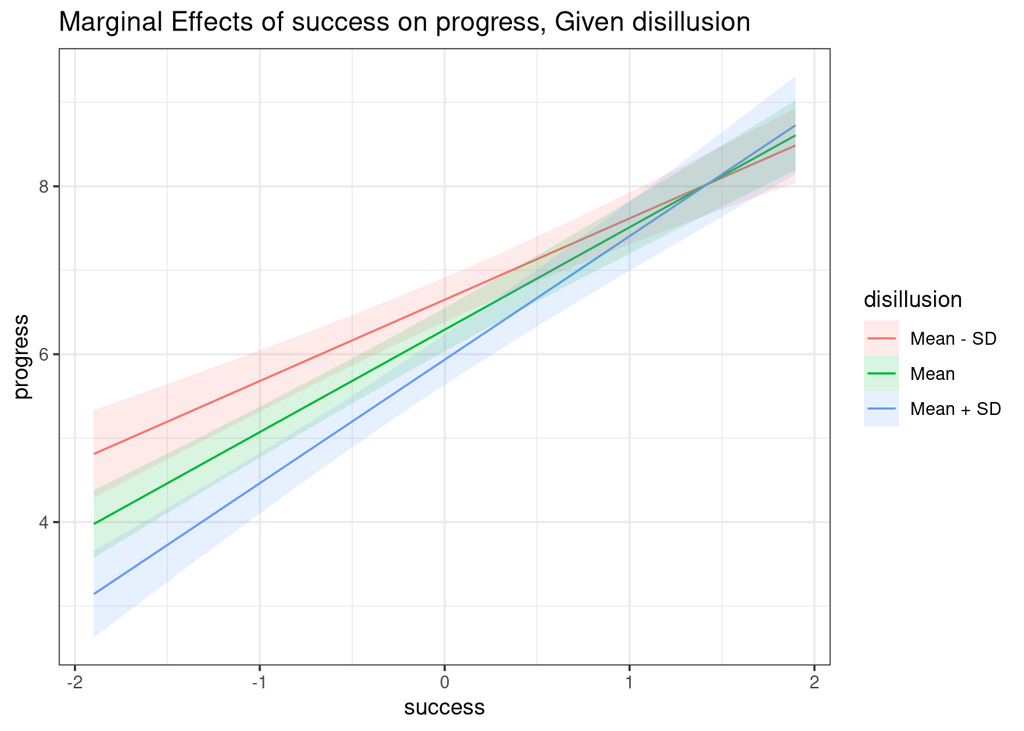

```r
# Make some pretty labels:
zLabels <- c("Mean - SD", "Mean", "Mean + SD")

# Generate a simple slopes plot:
plot_interaction(model = lmsFit,
                 y = "progress",
                 x = "success",
                 z = "disillusion",
                 vals_z = c(-1, 0, 1),
                 rescale = TRUE) +
  scale_color_discrete(labels = zLabels) +
  scale_fill_discrete(labels = zLabels)
```

# 2 Categorical Moderators

Now, we will move on to consider categorical moderators. That is, situations wherein we hypothesize different focal effects in the different groups define by some discrete moderator variable.

We will first evaluate such a hypothesis using OLS regression and path analysis while treating the moderator as a dummy-coded predictor. Then, we will consider ways of evaluating this hypothesis when the focal effect is defined by a latent regression model and the moderation is modeled via multiple-group SEM. In the context of multiple-group SEM, we will consider several different ways of *testing* the moderation hypothesis, given the same SEM.

## 2.1 Data

To explore moderation analysis with categorical moderators, we will go back to the classic Holzinger & Swineford (1939) educational testing data. You can access the dataset as [*holzinger_swineford.rds*](https://github.com/kylelang/lavaan-e-learning/raw/main/data/holzinger_swineford.rds).

These data contain a number of educational test scores from 7th and 8th grade students in two schools. This dataset comprises 301 observations of the following 29 variables.

- `id`: Numeric ID $\\[6pt]$
- `age`: Student age in years $\\[6pt]$
- `sex`: Biological sex of the student $\\[6pt]$
- `grade`: Grade of the student $\\[6pt]$
- `school`: School at which the student was tested $\\[6pt]$
- `spatial1:spatial4`: Scores on four spatial reasoning tests $\\[6pt]$
- `verbal1:verbal5`: Scores on five tests of verbal ability $\\[6pt]$
- `speed1:speed4`: Scores on four tests of cognitive processing speed $\\[6pt]$
- `memory1:memory6`: Scores on six memory tests $\\[6pt]$
- `math1:math5`: Scores on five tests of mathematical ability

You can access the original version of the data via the [**MBESS**](https://cran.r-project.org/web/packages/MBESS/index.html) package, and you can access the code used to process the data [here](https://github.com/kylelang/lavaan-e-learning/blob/main/code/lab_prep/process_hs_data.R).

### 2.1.1

**Read in the *holzinger_swineford.rds* dataset.**

```r
hs <- readRDS(here::here(dataDir, "holzinger_swineford.rds"))
```

NOTES:

1. In the following, I will refer to these data as the *HS data*.
2. You should have already summarized the HS data at the beginning of the last lab, so we won’t do so again here. That being said, if you don’t remember what’s going on in there, it may be a good idea to rerun the summaries you conducted for Lab 4.

### 2.1.2

**Run the following code to create scale scores.**

The following code will use the `scoreVeryFast()` function from the [**psych**](https://cran.r-project.org/web/packages/psych/index.html) package to create scale scores for the *math*, *verbal*, and *memory* constructs.

```r
## Load the 'psych' package for scoring utilities:
library(psych)

## Define the subscale mappings:
keys <- list(math   = paste0("math", 1:5),
             verbal = paste0("verbal", 1:5),
             memory = paste0("memory", 1:6)
             )

## Create scale scores (i.e., mean scores):
scores <- scoreVeryFast(keys = keys, items = hs)

## Create a new dataset:
hs2 <- data.frame(scores, sex = hs$sex)
```

## 2.2 OLS Regression

We will consider a model wherein student’s sex, *sex*, moderates two focal effects:

1. The effect of verbal ability, *verbal*, on mathematical ability, *math*
2. The effect of memory ability, *memory*, on *math*

We may hypothesize such a model if we believe that verbal ability and memory ability are both positively associated with mathematical ability but the strengths of these effects differ for boys and girls.

- E.g., perhaps the effect of *verbal* on *math* is stronger for girls because girls are enculturated to process information using language pathways whereas boys are enculturated to process information via visio-spatial.

### 2.2.1

**Draw the conceptual path diagram for the model described above.**

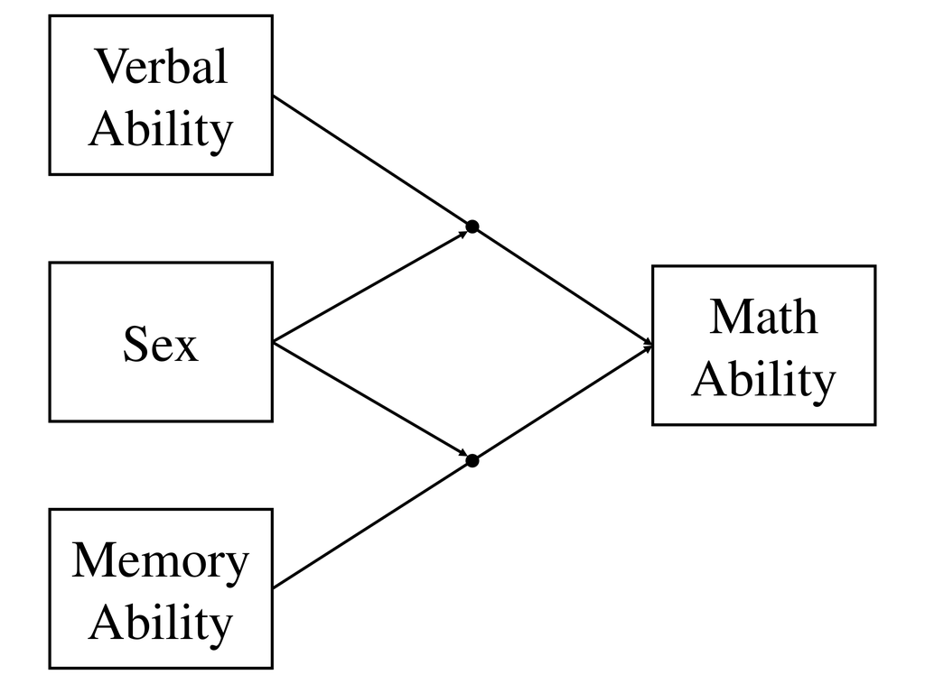

### 2.2.2

**Draw the analytic path diagram for the model described above.**

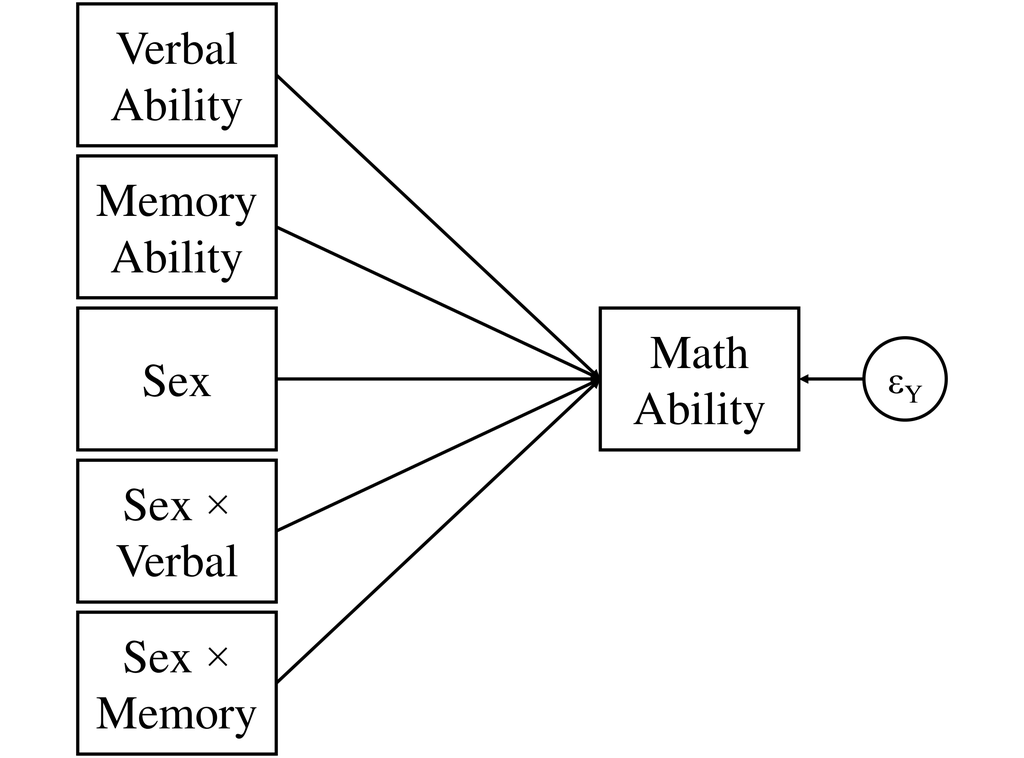

### 2.2.3

**Write out the regression equation necessary to evaluate the moderation hypothesis described above.**

$$Y_{math} = \beta_0 + \beta_1 X_{verbal} + \beta_2 W_{memory} + \beta_3 Z_{sex} + \beta_4 XZ + \beta_5 WZ + \varepsilon$$

### 2.2.4

**Use `lm()` to estimate the moderated regression model described above.**

```r
olsFit <- lm(math ~ verbal * sex + memory * sex, data = hs2)
```

### 2.2.5

**Summarize the model from 2.2.4 and interpret the results.**

- Does the student’s sex moderate the effect of verbal ability on mathematical ability?
- Does the student’s sex moderate the effect of memory ability on mathematical ability?

```r
summary(olsFit)
```

```
Call:
lm(formula = math ~ verbal * sex + memory * sex, data = hs2)

Residuals:
     Min       1Q   Median       3Q      Max
-1.48321 -0.31164  0.00321  0.32777  2.00834

Coefficients:
               Estimate Std. Error t value Pr(>|t|)
(Intercept)    -0.07847    0.04195  -1.870  0.06241 .
verbal          0.55589    0.05086  10.929  < 2e-16 ***
sexMale         0.17460    0.06021   2.900  0.00402 **
memory          0.29481    0.07325   4.025 7.25e-05 ***
verbal:sexMale -0.22219    0.07279  -3.052  0.00248 **
sexMale:memory  0.19259    0.09874   1.951  0.05205 .
---
Signif. codes:  0 '***' 0.001 '**' 0.01 '*' 0.05 '.' 0.1 ' ' 1

Residual standard error: 0.516 on 295 degrees of freedom
Multiple R-squared:  0.5166,    Adjusted R-squared:  0.5084
F-statistic: 63.05 on 5 and 295 DF,  p-value: < 2.2e-16
```

- Yes, *sex* significantly moderates the relation between *verbal* and *math* $(\beta = -0.222,$ $t(295) = -3.052,$ $p = 0.002),$ after controlling for *memory* and its interaction with *sex*. The effect of *verbal* on *math* is significantly smaller for boys.
- No, *sex* does not significantly moderate the relation between *memory* and *math* $(\beta = 0.193,$ $t(295) = 1.951,$ $p = 0.052),$ after controlling for *verbal* and its interaction with *sex*.

## 2.3 Path Analysis

### 2.3.1

**Rerun the analysis from 2.2.4 using path analysis in *lavaan*.**

```r
## Define the syntax for the path model:
pathMod <- '
math ~ 1 + verbal + memory + male + verbal:male + memory:male
'

## Use a dplyr pipeline to dummy code 'sex' and estimate the model:
pathFit <- hs2 |>
    mutate(male = as.numeric(sex == "Male")) |>
    sem(pathMod, data = _)
```

### 2.3.2

**Summarize the model from 2.3.1 and interpret the results.**

- Do the results match the findings from the OLS regression analysis?

```r
summary(pathFit)
```

```
lavaan 0.6-21 ended normally after 1 iteration

  Estimator                                         ML
  Optimization method                           NLMINB
  Number of model parameters                         7

  Number of observations                           301

Model Test User Model:

  Test statistic                                 0.000
  Degrees of freedom                                 0

Parameter Estimates:

  Standard errors                             Standard
  Information                                 Expected
  Information saturated (h1) model          Structured

Regressions:
                   Estimate  Std.Err  z-value  P(>|z|)
  math ~
    verbal            0.556    0.050   11.040    0.000
    memory            0.295    0.073    4.066    0.000
    male              0.175    0.060    2.929    0.003
    verbal:male      -0.222    0.072   -3.083    0.002
    memory:male       0.193    0.098    1.970    0.049

Intercepts:
                   Estimate  Std.Err  z-value  P(>|z|)
   .math             -0.078    0.042   -1.889    0.059

Variances:
                   Estimate  Std.Err  z-value  P(>|z|)
   .math              0.261    0.021   12.268    0.000
```

- Yes, the results are largely the same as those from the OLS regression model, but *sex* now significantly—if only just—moderates the *memory* to *math* effect $(\beta = 0.193,$ $z = 1.97,$ $p = 0.049).$
  - This difference is attributable to slightly more precise estimates in the path model. As you can see in Table 2.1, the point estimates are essentially identical, but the standard errors are a little smaller in the path model.

Table 2.1: OLS vs. PA Comparison

| Predictor | Method | Estimate | SE |
| --- | --- | --- | --- |
| memory | OLS | 0.1925939 | 0.0987373 |
| memory | PA | 0.1925939 | 0.0977482 |
| verbal | OLS | -0.2221859 | 0.0727916 |
| verbal | PA | -0.2221859 | 0.0720624 |

## 2.4 Multiple Group SEM

Now, we will evaluate the moderation hypotheses considered above using multiple group SEM. By defining the *math*, *verbal*, and *memory* constructs as latent variables we gain two substantial advantages over the preceding path analysis:

1. We will remove measurement error from the definition of the *math*, *verbal*, and *memory* variables.
2. We will have the ability to evaluate the equivalence of these constructs’ measurement structure in the boys’ and girls’ samples.

### 2.4.1

**Define the model syntax for the CFA.**

- Indicated the *mathematical ability* factor from the five observed math test scores.
  - `math1:math5`
- Indicated the *verbal ability* factor from the five observed verbal test scores.
  - `verbal1:verbal5`
- Indicated the *memory ability* factor from the six observed memory test scores.
  - `memory1:memory6`

```r
cfaMod <- '
math   =~ math1   + math2   + math3   + math4   + math5
verbal =~ verbal1 + verbal2 + verbal3 + verbal4 + verbal5
memory =~ memory1 + memory2 + memory3 + memory4 + memory5 + memory6
'
```

### 2.4.2

**Estimate the configurally invariant CFA model using the HS data.**

- Define the groups via the *sex* factor.
- Correlate all latent factors.
- Estimate the mean structure.
- Set the scale by standardizing the latent variables.

```r
configFit <- cfa(cfaMod, data = hs, std.lv = TRUE, group = "sex")
```

### 2.4.3

**Summarize the model from 2.4.2 and interpret the results.**

- Does the model seem sensible?
- Does the model fit the data well enough?
- Is configural invariance supported?

```r
summary(configFit)
```

```
lavaan 0.6-21 ended normally after 27 iterations

  Estimator                                         ML
  Optimization method                           NLMINB
  Number of model parameters                       102

  Number of observations per group:
    Male                                           146
    Female                                         155

Model Test User Model:

  Test statistic                               282.889
  Degrees of freedom                               202
  P-value (Chi-square)                           0.000
  Test statistic for each group:
    Male                                       144.140
    Female                                     138.750

Parameter Estimates:

  Standard errors                             Standard
  Information                                 Expected
  Information saturated (h1) model          Structured


Group 1 [Male]:

Latent Variables:
                   Estimate  Std.Err  z-value  P(>|z|)
  math =~
    math1             0.718    0.085    8.467    0.000
    math2             0.575    0.077    7.488    0.000
    math3             0.647    0.087    7.469    0.000
    math4             0.659    0.078    8.480    0.000
    math5             0.573    0.076    7.508    0.000
  verbal =~
    verbal1           0.859    0.070   12.288    0.000
    verbal2           0.781    0.066   11.764    0.000
    verbal3           0.850    0.065   13.052    0.000
```

[output cut: 117 more lines]

```
   .math5             0.561    0.073    7.652    0.000
   .verbal1           0.258    0.036    7.122    0.000
   .verbal2           0.325    0.044    7.389    0.000
   .verbal3           0.277    0.039    7.052    0.000
   .verbal4           0.398    0.051    7.888    0.000
   .verbal5           0.232    0.036    6.527    0.000
   .memory1           0.551    0.072    7.600    0.000
   .memory2           0.710    0.089    7.992    0.000
   .memory3           0.638    0.097    6.548    0.000
   .memory4           0.775    0.099    7.832    0.000
   .memory5           0.690    0.090    7.654    0.000
   .memory6           0.829    0.104    7.945    0.000
    math              1.000
    verbal            1.000
    memory            1.000
```

```r
fitMeasures(configFit)
```

```
                 npar                  fmin                 chisq
              102.000                 0.470               282.889
                   df                pvalue        baseline.chisq
              202.000                 0.000              2191.826
          baseline.df       baseline.pvalue                   cfi
              240.000                 0.000                 0.959
                  tli                  nnfi                   rfi
                0.951                 0.951                 0.847
                  nfi                  pnfi                   ifi
                0.871                 0.733                 0.959
                  rni                  logl     unrestricted.logl
                0.959             -5833.379             -5691.935
                  aic                   bic                ntotal
            11870.759             12248.884               301.000
                 bic2                 rmsea        rmsea.ci.lower
            11925.398                 0.052                 0.036
       rmsea.ci.upper        rmsea.ci.level          rmsea.pvalue
                0.065                 0.900                 0.416
       rmsea.close.h0 rmsea.notclose.pvalue     rmsea.notclose.h0
                0.050                 0.000                 0.080
                  rmr            rmr_nomean                  srmr
                0.064                 0.068                 0.064
         srmr_bentler   srmr_bentler_nomean                  crmr
                0.064                 0.068                 0.068
          crmr_nomean            srmr_mplus     srmr_mplus_nomean
                0.072                 0.064                 0.068
                cn_05                 cn_01                   gfi
              252.277               268.790                 0.904
                 agfi                  pgfi                   mfi
                0.855                 0.600                 0.874
                 ecvi
                1.618
```

Yes, the model looks good. All parameter estimates look reasonable, and the model fits well. Therefore, configural invariance is supported.

### 2.4.4

**Test weak and strong invariance for the CFA define in 2.4.1.**

- Is weak invariance supported?
- Is strong invariance supported?
- Based on these findings, can we proceed to testing moderation by group?

*HINT*: The **semTools** functions `measEq.syntax()` and `compareFit()` can be very helpful here.

```r
## Define the syntax for the weakly invariant model:
weakMod <- measEq.syntax(configFit, group.equal = "loadings") |> as.character()

## Estimate the weakly invariant model:
weakFit <- cfa(weakMod, data = hs, std.lv = TRUE, group = "sex")

## Summarize the fitted weakly invariant model:
summary(weakFit)
```

```
lavaan 0.6-21 ended normally after 49 iterations

  Estimator                                         ML
  Optimization method                           NLMINB
  Number of model parameters                       105
  Number of equality constraints                    16

  Number of observations per group:
    Male                                           146
    Female                                         155

Model Test User Model:

  Test statistic                               300.099
  Degrees of freedom                               215
  P-value (Chi-square)                           0.000
  Test statistic for each group:
    Male                                       154.169
    Female                                     145.930

Parameter Estimates:

  Standard errors                             Standard
  Information                                 Expected
  Information saturated (h1) model          Structured


Group 1 [Male]:

Latent Variables:
                   Estimate  Std.Err  z-value  P(>|z|)
  math =~
    math1   (l.1_)    0.564    0.062    9.164    0.000
    math2   (l.2_)    0.583    0.062    9.468    0.000
    math3   (l.3_)    0.634    0.063   10.007    0.000
    math4   (l.4_)    0.708    0.065   10.955    0.000
    math5   (l.5_)    0.631    0.062   10.122    0.000
  verbal =~
    verbal1 (l.6_)    0.810    0.059   13.669    0.000
    verbal2 (l.7_)    0.793    0.059   13.503    0.000
```

[output cut: 118 more lines]

```
   .math5   (t.5_)    0.577    0.073    7.868    0.000
   .verbal1 (t.6_)    0.256    0.037    7.014    0.000
   .verbal2 (t.7_)    0.327    0.044    7.472    0.000
   .verbal3 (t.8_)    0.273    0.039    7.016    0.000
   .verbal4 (t.9_)    0.397    0.050    7.908    0.000
   .verbal5 (t.10)    0.240    0.035    6.806    0.000
   .memory1 (t.11)    0.527    0.073    7.254    0.000
   .memory2 (t.12)    0.696    0.088    7.886    0.000
   .memory3 (t.13)    0.676    0.092    7.354    0.000
   .memory4 (t.14)    0.767    0.096    8.000    0.000
   .memory5 (t.15)    0.701    0.089    7.909    0.000
   .memory6 (t.16)    0.837    0.103    8.104    0.000
    math    (p.1_)    1.175    0.243    4.839    0.000
    verbal  (p.2_)    1.123    0.199    5.628    0.000
    memory  (p.3_)    0.825    0.191    4.323    0.000
```

```r
fitMeasures(weakFit)
```

```
                 npar                  fmin                 chisq
               89.000                 0.499               300.099
                   df                pvalue        baseline.chisq
              215.000                 0.000              2191.826
          baseline.df       baseline.pvalue                   cfi
              240.000                 0.000                 0.956
                  tli                  nnfi                   rfi
                0.951                 0.951                 0.847
                  nfi                  pnfi                   ifi
                0.863                 0.773                 0.957
                  rni                  logl     unrestricted.logl
                0.956             -5841.984             -5691.935
                  aic                   bic                ntotal
            11861.968             12191.901               301.000
                 bic2                 rmsea        rmsea.ci.lower
            11909.643                 0.051                 0.037
       rmsea.ci.upper        rmsea.ci.level          rmsea.pvalue
                0.065                 0.900                 0.428
       rmsea.close.h0 rmsea.notclose.pvalue     rmsea.notclose.h0
                0.050                 0.000                 0.080
                  rmr            rmr_nomean                  srmr
                0.073                 0.077                 0.072
         srmr_bentler   srmr_bentler_nomean                  crmr
                0.072                 0.076                 0.071
          crmr_nomean            srmr_mplus     srmr_mplus_nomean
                0.076                 0.069                 0.073
                cn_05                 cn_01                   gfi
              251.959               267.959                 0.900
                 agfi                  pgfi                   mfi
                0.859                 0.637                 0.868
                 ecvi
                1.588
```

```r
## Define the syntax for the strongly invariant model:
strongMod <-
  measEq.syntax(configFit, group.equal = c("loadings", "intercepts")) |>
  as.character()

## Estimate the strongly invariant model:
strongFit <- cfa(strongMod, data = hs, std.lv = TRUE, group = "sex")

## Summarize the fitted strongly invariant model:
summary(strongFit)
```

```
lavaan 0.6-21 ended normally after 54 iterations

  Estimator                                         ML
  Optimization method                           NLMINB
  Number of model parameters                       108
  Number of equality constraints                    32

  Number of observations per group:
    Male                                           146
    Female                                         155

Model Test User Model:

  Test statistic                               359.618
  Degrees of freedom                               228
  P-value (Chi-square)                           0.000
  Test statistic for each group:
    Male                                       184.245
    Female                                     175.374

Parameter Estimates:

  Standard errors                             Standard
  Information                                 Expected
  Information saturated (h1) model          Structured


Group 1 [Male]:

Latent Variables:
                   Estimate  Std.Err  z-value  P(>|z|)
  math =~
    math1   (l.1_)    0.569    0.062    9.153    0.000
    math2   (l.2_)    0.584    0.062    9.462    0.000
    math3   (l.3_)    0.636    0.063   10.014    0.000
    math4   (l.4_)    0.711    0.065   10.962    0.000
    math5   (l.5_)    0.619    0.063    9.900    0.000
  verbal =~
    verbal1 (l.6_)    0.801    0.059   13.465    0.000
    verbal2 (l.7_)    0.795    0.059   13.429    0.000
```

[output cut: 124 more lines]

```
   .math5   (t.5_)    0.603    0.076    7.938    0.000
   .verbal1 (t.6_)    0.272    0.038    7.123    0.000
   .verbal2 (t.7_)    0.337    0.045    7.477    0.000
   .verbal3 (t.8_)    0.272    0.039    6.969    0.000
   .verbal4 (t.9_)    0.395    0.050    7.885    0.000
   .verbal5 (t.10)    0.241    0.036    6.783    0.000
   .memory1 (t.11)    0.525    0.073    7.166    0.000
   .memory2 (t.12)    0.706    0.089    7.969    0.000
   .memory3 (t.13)    0.707    0.094    7.542    0.000
   .memory4 (t.14)    0.786    0.100    7.896    0.000
   .memory5 (t.15)    0.699    0.089    7.891    0.000
   .memory6 (t.16)    0.838    0.103    8.113    0.000
    math    (p.1_)    1.171    0.243    4.826    0.000
    verbal  (p.2_)    1.128    0.201    5.617    0.000
    memory  (p.3_)    0.818    0.190    4.297    0.000
```

```r
fitMeasures(strongFit)
```

```
                 npar                  fmin                 chisq
               76.000                 0.597               359.618
                   df                pvalue        baseline.chisq
              228.000                 0.000              2191.826
          baseline.df       baseline.pvalue                   cfi
              240.000                 0.000                 0.933
                  tli                  nnfi                   rfi
                0.929                 0.929                 0.827
                  nfi                  pnfi                   ifi
                0.836                 0.794                 0.933
                  rni                  logl     unrestricted.logl
                0.933             -5871.744             -5691.935
                  aic                   bic                ntotal
            11895.487             12177.228               301.000
                 bic2                 rmsea        rmsea.ci.lower
            11936.199                 0.062                 0.049
       rmsea.ci.upper        rmsea.ci.level          rmsea.pvalue
                0.074                 0.900                 0.057
       rmsea.close.h0 rmsea.notclose.pvalue     rmsea.notclose.h0
                0.050                 0.006                 0.080
                  rmr            rmr_nomean                  srmr
                0.078                 0.078                 0.078
         srmr_bentler   srmr_bentler_nomean                  crmr
                0.078                 0.077                 0.077
          crmr_nomean            srmr_mplus     srmr_mplus_nomean
                0.077                 0.075                 0.074
                cn_05                 cn_01                   gfi
              222.155               235.859                 0.877
                 agfi                  pgfi                   mfi
                0.836                 0.658                 0.804
                 ecvi
                1.700
```

```r
## Compare model fits to test weak and strong invariance:
compareFit(configFit, weakFit, strongFit) |> summary()
```

```
################### Nested Model Comparison #########################

Chi-Squared Difference Test

           Df   AIC   BIC  Chisq Chisq diff    RMSEA Df diff Pr(>Chisq)
configFit 202 11871 12249 282.89
weakFit   215 11862 12192 300.10     17.209 0.046382      13     0.1899
strongFit 228 11896 12177 359.62     59.520 0.154198      13  6.402e-08 ***
---
Signif. codes:  0 '***' 0.001 '**' 0.01 '*' 0.05 '.' 0.1 ' ' 1

####################### Model Fit Indices ###########################
             chisq  df pvalue rmsea   cfi   tli  srmr        aic        bic
configFit 282.889† 202   .000 .052  .959† .951  .064† 11870.759  12248.884
weakFit   300.099  215   .000 .051† .956  .951† .072  11861.968† 12191.901
strongFit 359.618  228   .000 .062  .933  .929  .078  11895.487  12177.228†

################## Differences in Fit Indices #######################
                    df rmsea    cfi    tli  srmr    aic     bic
weakFit - configFit 13 0.000 -0.002  0.001 0.008 -8.791 -56.983
strongFit - weakFit 13 0.011 -0.024 -0.022 0.005 33.520 -14.673
```

### 2.4.5

**Define the syntax for the structural model.**

- Regress *math* onto *verbal* and *memory*.
- Give the $\eta_{verbal} \rightarrow \eta_{math}$ effect a unique label in each group.
- Give the $\eta_{memory} \rightarrow \eta_{math}$ effect a unique label in each group.
- Only include the intercept if you were able to establish a sufficient level of measurement invariance in 2.4.4.

```r
## Paste the new line of model syntax onto the syntax for the CFA model:
## NOTE: We only established weak invariance, so we will not estimate an
##       intercept for this latent regression.
semMod <- paste(cfaMod,
                'math ~ c(b1m, b1f) * verbal + c(b2m, b2f) * memory',
                  sep = '\n')
```

### 2.4.6

**Estimate the unrestricted, multiple group SEM.**

- Covary the *verbal* and *memory* factors.
- Enforce whatever level of invariance constraints were supported by the analysis in 2.4.4.
- Only estimate the mean structure if you were able to establish a sufficient level of measurement invariance in 2.4.4.
- Set the scale by standardizing the latent variables.

```r
## NOTE: We only established weak invariance, so we will not equate the item
##       intercepts across groups nor estimate a mean structure.
semFit <- sem(semMod,
              data        = hs,
              std.lv      = TRUE,
              group       = "sex",
              group.equal = "loadings")

## Check the results:
summary(semFit)
```

```
lavaan 0.6-21 ended normally after 53 iterations

  Estimator                                         ML
  Optimization method                           NLMINB
  Number of model parameters                       105
  Number of equality constraints                    16

  Number of observations per group:
    Male                                           146
    Female                                         155

Model Test User Model:

  Test statistic                               300.099
  Degrees of freedom                               215
  P-value (Chi-square)                           0.000
  Test statistic for each group:
    Male                                       154.169
    Female                                     145.930

Parameter Estimates:

  Standard errors                             Standard
  Information                                 Expected
  Information saturated (h1) model          Structured


Group 1 [Male]:

Latent Variables:
                   Estimate  Std.Err  z-value  P(>|z|)
  math =~
    math1   (.p1.)    0.331    0.052    6.370    0.000
    math2   (.p2.)    0.343    0.053    6.465    0.000
    math3   (.p3.)    0.373    0.056    6.628    0.000
    math4   (.p4.)    0.416    0.061    6.860    0.000
    math5   (.p5.)    0.371    0.056    6.654    0.000
  verbal =~
    verbal1 (.p6.)    0.810    0.059   13.669    0.000
    verbal2 (.p7.)    0.793    0.059   13.503    0.000
```

[output cut: 124 more lines]

```
   .math5             0.577    0.073    7.868    0.000
   .verbal1           0.256    0.037    7.014    0.000
   .verbal2           0.327    0.044    7.472    0.000
   .verbal3           0.273    0.039    7.016    0.000
   .verbal4           0.397    0.050    7.908    0.000
   .verbal5           0.240    0.035    6.806    0.000
   .memory1           0.527    0.073    7.254    0.000
   .memory2           0.696    0.088    7.886    0.000
   .memory3           0.676    0.092    7.354    0.000
   .memory4           0.767    0.096    8.000    0.000
   .memory5           0.701    0.089    7.909    0.000
   .memory6           0.837    0.103    8.104    0.000
   .math              0.643    0.262    2.449    0.014
    verbal            1.123    0.199    5.628    0.000
    memory            0.825    0.191    4.323    0.000
```

## 2.5 Testing for Moderation

The unrestricted SEM we fit in 2.4.6 directly estimates unique focal effects in each group. In other words, this model allows *sex* to fully moderate the $\eta_{verbal} \rightarrow \eta_{math}$ effect and the $\eta_{memory} \rightarrow \eta_{math}$ effect and directly estimates all the simple slopes for these two focal effects.

We cannot directly test for moderation using only the unrestricted SEM, but we have several different options for conducting such a test. In the next several questions, we will explore three of these options.

One of the simplest ways to test the moderation hypotheses we’re considering here is to define a new parameter that represents the difference between the simple slopes (i.e., the group-specific focal effect estimates). Testing the null hypothesis that this difference is zero is also a test of moderation. Rejecting the null hypothesis implies significantly different focal effects between groups, hence moderation by group.

### 2.5.1

**Test for moderation using defined parameters.**

- Modify the model syntax from 2.4.5 by including two defined parameters.
  1. The first defined parameter should quantify the moderating effect of *sex* on the $\eta_{verbal} \rightarrow \eta_{math}$ effect.
  2. The second defined parameter should quantify the moderating effect of *sex* on the $\eta_{memory} \rightarrow \eta_{math}$ effect.
- Evaluate these two moderation hypotheses via the normal-theory z-tests of the defined parameters.
- Are the hypotheses supported?
- Are we violating any of the assumptions of the above z-tests by using them to test differences between two slopes? Are the inferences based on these tests valid?

```r
## Add defined parameters to the SEM syntax:
semMod2 <- paste(semMod,
                 'verbalDiff := b1f - b1m',
                 'memoryDiff := b2f - b2m',
                 sep = '\n')

## Estimate the model with the defined parameters:
semFit2 <- sem(semMod2,
               data        = hs,
               std.lv      = TRUE,
               group       = "sex",
               group.equal = "loadings")

## Summarize the fitted model:
summary(semFit2)
```

```
lavaan 0.6-21 ended normally after 53 iterations

  Estimator                                         ML
  Optimization method                           NLMINB
  Number of model parameters                       105
  Number of equality constraints                    16

  Number of observations per group:
    Male                                           146
    Female                                         155

Model Test User Model:

  Test statistic                               300.099
  Degrees of freedom                               215
  P-value (Chi-square)                           0.000
  Test statistic for each group:
    Male                                       154.169
    Female                                     145.930

Parameter Estimates:

  Standard errors                             Standard
  Information                                 Expected
  Information saturated (h1) model          Structured


Group 1 [Male]:

Latent Variables:
                   Estimate  Std.Err  z-value  P(>|z|)
  math =~
    math1   (.p1.)    0.331    0.052    6.370    0.000
    math2   (.p2.)    0.343    0.053    6.465    0.000
    math3   (.p3.)    0.373    0.056    6.628    0.000
    math4   (.p4.)    0.416    0.061    6.860    0.000
    math5   (.p5.)    0.371    0.056    6.654    0.000
  verbal =~
    verbal1 (.p6.)    0.810    0.059   13.669    0.000
    verbal2 (.p7.)    0.793    0.059   13.503    0.000
```

[output cut: 129 more lines]

```
   .verbal5           0.240    0.035    6.806    0.000
   .memory1           0.527    0.073    7.254    0.000
   .memory2           0.696    0.088    7.886    0.000
   .memory3           0.676    0.092    7.354    0.000
   .memory4           0.767    0.096    8.000    0.000
   .memory5           0.701    0.089    7.909    0.000
   .memory6           0.837    0.103    8.104    0.000
   .math              0.643    0.262    2.449    0.014
    verbal            1.123    0.199    5.628    0.000
    memory            0.825    0.191    4.323    0.000

Defined Parameters:
                   Estimate  Std.Err  z-value  P(>|z|)
    verbalDiff        0.554    0.203    2.731    0.006
    memoryDiff       -0.413    0.239   -1.727    0.084
```

- Yes, *sex* significantly moderates the effect of *verbal* on *math* $(\Delta \beta = 0.554,$ $z = 2.73,$ $p = 0.006)$
- No, *sex* does not significantly moderate the effect of *memory* on *math* $(\Delta \beta = -0.413,$ $z = -1.73,$ $p = 0.084)$
- These results are valid; we are not violating any assumptions of the z-test. The simple slopes are normally distributed in each group, so their difference is also normally distributed.

We can also test these types of moderation hypotheses using multivariate Wald tests to evaluate the relevant equality constraints. In **lavaan**, we can use the `lavTestWald()` function to implement such tests directly on the fitted, unrestricted SEM.

### 2.5.2

**Rerun the analysis from 2.5.1 using the `lavTestWald()` function.**

- Run the tests using the fitted model from 2.4.6.
- Test each moderation hypothesis independently.
- Are the moderation hypotheses supported from these tests?

```r
(verbalWald <- lavTestWald(semFit, 'b1m == b1f'))
```

```
$stat
[1] 7.460556

$df
[1] 1

$p.value
[1] 0.006306554

$se
[1] "standard"
```

```r
(memoryWald <- lavTestWald(semFit, 'b2m == b2f'))
```

```
$stat
[1] 2.983319

$df
[1] 1

$p.value
[1] 0.08412659

$se
[1] "standard"
```

### 2.5.3

**Compare the results from 2.5.1 and 2.5.2.**

- Do the tests agree?
- What do you notice about the estimates associated with each test (e.g., test statistics, p-values)?

```r
## Compare p-values:
parameterEstimates(semFit2) |>
  filter(label %in% c("verbalDiff", "memoryDiff")) |>
  select(label, pvalue)
```

| label | pvalue |
| --- | --- |
| verbalDiff | 0.006306554 |
| memoryDiff | 0.084126589 |

```r
verbalWald$p.value
```

```
[1] 0.006306554
```

```r
memoryWald$p.value
```

```
[1] 0.08412659
```

```r
## Compare test statistics:
parameterEstimates(semFit2) |>
  filter(label %in% c("verbalDiff", "memoryDiff")) |>
  select(label, z)
```

| label | z |
| --- | --- |
| verbalDiff | 2.731402 |
| memoryDiff | -1.727229 |

```r
verbalWald$stat |> sqrt()
```

```
[1] 2.731402
```

```r
memoryWald$stat |> sqrt()
```

```
[1] 1.727229
```

Yes, both tests agree and produce identical p-values. Furthermore, the Wald test statistics are equal to the square of the z-statistics for the defined parameters.

The final option we will consider is the likelihood ratio test (i.e., $\Delta \chi^2$ test). Testing moderation via a likelihood ratio test involves two steps:

1. Estimate a restricted model wherein the relevant simple slopes are equated across groups
2. Evaluate the tenability of these constraints via a likelihood ratio test

### 2.5.4

**Test the moderation hypotheses using likelihood ratio tests.**

- Define restricted models by modifying the unrestricted SEM syntax from 2.4.5 to introduce the appropriate equality constraints.
- Test each moderation hypothesis independently.
- Are the moderation hypotheses supported from these tests?

**Option 1**

```r
## Add equality constraints to the unrestricted SEM syntax:
semMod3.1 <- paste(semMod, 'b1m == b1f', sep = '\n')
semMod3.2 <- paste(semMod, 'b2m == b2f', sep = '\n')

## Estimate the restricted models:
semFit3.1 <- sem(semMod3.1,
                 data        = hs,
                 std.lv      = TRUE,
                 group       = "sex",
                 group.equal = "loadings")
semFit3.2 <- sem(semMod3.2,
                 data        = hs,
                 std.lv      = TRUE,
                 group       = "sex",
                 group.equal = "loadings")

## Check the results:
summary(semFit3.1)
```

```
lavaan 0.6-21 ended normally after 51 iterations

  Estimator                                         ML
  Optimization method                           NLMINB
  Number of model parameters                       105
  Number of equality constraints                    17

  Number of observations per group:
    Male                                           146
    Female                                         155

Model Test User Model:

  Test statistic                               308.882
  Degrees of freedom                               216
  P-value (Chi-square)                           0.000
  Test statistic for each group:
    Male                                       158.621
    Female                                     150.261

Parameter Estimates:

  Standard errors                             Standard
  Information                                 Expected
  Information saturated (h1) model          Structured


Group 1 [Male]:

Latent Variables:
                   Estimate  Std.Err  z-value  P(>|z|)
  math =~
    math1   (.p1.)    0.344    0.052    6.593    0.000
    math2   (.p2.)    0.353    0.053    6.704    0.000
    math3   (.p3.)    0.391    0.057    6.892    0.000
    math4   (.p4.)    0.429    0.060    7.120    0.000
    math5   (.p5.)    0.378    0.055    6.872    0.000
  verbal =~
    verbal1 (.p6.)    0.799    0.059   13.651    0.000
    verbal2 (.p7.)    0.785    0.058   13.493    0.000
```

[output cut: 124 more lines]

```
   .math5             0.588    0.074    7.899    0.000
   .verbal1           0.253    0.036    6.953    0.000
   .verbal2           0.327    0.044    7.438    0.000
   .verbal3           0.271    0.039    6.957    0.000
   .verbal4           0.398    0.050    7.894    0.000
   .verbal5           0.236    0.035    6.717    0.000
   .memory1           0.536    0.073    7.379    0.000
   .memory2           0.711    0.089    7.975    0.000
   .memory3           0.673    0.091    7.423    0.000
   .memory4           0.784    0.097    8.083    0.000
   .memory5           0.712    0.089    7.997    0.000
   .memory6           0.825    0.102    8.124    0.000
   .math              0.612    0.248    2.465    0.014
    verbal            1.171    0.208    5.643    0.000
    memory            0.801    0.186    4.309    0.000
```

```r
summary(semFit3.2)
```

```
lavaan 0.6-21 ended normally after 49 iterations

  Estimator                                         ML
  Optimization method                           NLMINB
  Number of model parameters                       105
  Number of equality constraints                    17

  Number of observations per group:
    Male                                           146
    Female                                         155

Model Test User Model:

  Test statistic                               303.236
  Degrees of freedom                               216
  P-value (Chi-square)                           0.000
  Test statistic for each group:
    Male                                       155.221
    Female                                     148.015

Parameter Estimates:

  Standard errors                             Standard
  Information                                 Expected
  Information saturated (h1) model          Structured


Group 1 [Male]:

Latent Variables:
                   Estimate  Std.Err  z-value  P(>|z|)
  math =~
    math1   (.p1.)    0.346    0.050    6.925    0.000
    math2   (.p2.)    0.363    0.051    7.097    0.000
    math3   (.p3.)    0.393    0.054    7.296    0.000
    math4   (.p4.)    0.438    0.058    7.613    0.000
    math5   (.p5.)    0.390    0.053    7.326    0.000
  verbal =~
    verbal1 (.p6.)    0.810    0.059   13.673    0.000
    verbal2 (.p7.)    0.793    0.059   13.500    0.000
```

[output cut: 124 more lines]

```
   .math5             0.579    0.074    7.864    0.000
   .verbal1           0.254    0.036    6.986    0.000
   .verbal2           0.328    0.044    7.467    0.000
   .verbal3           0.271    0.039    6.993    0.000
   .verbal4           0.398    0.050    7.906    0.000
   .verbal5           0.239    0.035    6.786    0.000
   .memory1           0.534    0.072    7.361    0.000
   .memory2           0.705    0.088    7.968    0.000
   .memory3           0.680    0.091    7.502    0.000
   .memory4           0.784    0.097    8.107    0.000
   .memory5           0.716    0.089    8.025    0.000
   .memory6           0.834    0.102    8.163    0.000
   .math              0.537    0.216    2.480    0.013
    verbal            1.124    0.200    5.629    0.000
    memory            0.730    0.163    4.475    0.000
```

```r
## Test for moderation of the verbal effect via a LRT:
anova(semFit, semFit3.1)
```

|  | Df | AIC | BIC | Chisq | Chisq diff | RMSEA | Df diff | Pr(>Chisq) |
| --- | --- | --- | --- | --- | --- | --- | --- | --- |
| semFit | 215 | 11861.97 | 12191.90 | 300.0985 | NA | NA | NA | NA |
| semFit3.1 | 216 | 11868.75 | 12194.98 | 308.8822 | 8.78373 | 0.2274184 | 1 | 0.00303929 |

```r
## Test for moderation of the memory effect via a LRT:
anova(semFit, semFit3.2)
```

|  | Df | AIC | BIC | Chisq | Chisq diff | RMSEA | Df diff | Pr(>Chisq) |
| --- | --- | --- | --- | --- | --- | --- | --- | --- |
| semFit | 215 | 11861.97 | 12191.90 | 300.0985 | NA | NA | NA | NA |
| semFit3.2 | 216 | 11863.11 | 12189.33 | 303.2359 | 3.137376 | 0.1191714 | 1 | 0.07651683 |

**Option 2**

```r
## Constrain the parameters by assigning the same labels:
semMod4.1 <- gsub("b1m|b1f", "b1", semMod)
semMod4.2 <- gsub("b2m|b2f", "b2", semMod)

## Estimate the restricted models:
semFit4.1 <- sem(semMod4.1,
                 data        = hs,
                 std.lv      = TRUE,
                 group       = "sex",
                 group.equal = "loadings")
semFit4.2 <- sem(semMod4.2,
                 data        = hs,
                 std.lv      = TRUE,
                 group       = "sex",
                 group.equal = "loadings")

## Check the results:
summary(semFit4.1)
```

```
lavaan 0.6-21 ended normally after 51 iterations

  Estimator                                         ML
  Optimization method                           NLMINB
  Number of model parameters                       105
  Number of equality constraints                    17

  Number of observations per group:
    Male                                           146
    Female                                         155

Model Test User Model:

  Test statistic                               308.882
  Degrees of freedom                               216
  P-value (Chi-square)                           0.000
  Test statistic for each group:
    Male                                       158.621
    Female                                     150.261

Parameter Estimates:

  Standard errors                             Standard
  Information                                 Expected
  Information saturated (h1) model          Structured


Group 1 [Male]:

Latent Variables:
                   Estimate  Std.Err  z-value  P(>|z|)
  math =~
    math1   (.p1.)    0.344    0.052    6.593    0.000
    math2   (.p2.)    0.353    0.053    6.704    0.000
    math3   (.p3.)    0.391    0.057    6.892    0.000
    math4   (.p4.)    0.429    0.060    7.120    0.000
    math5   (.p5.)    0.378    0.055    6.873    0.000
  verbal =~
    verbal1 (.p6.)    0.799    0.059   13.651    0.000
    verbal2 (.p7.)    0.785    0.058   13.493    0.000
```

[output cut: 124 more lines]

```
   .math5             0.588    0.074    7.899    0.000
   .verbal1           0.253    0.036    6.953    0.000
   .verbal2           0.327    0.044    7.438    0.000
   .verbal3           0.271    0.039    6.957    0.000
   .verbal4           0.398    0.050    7.894    0.000
   .verbal5           0.236    0.035    6.717    0.000
   .memory1           0.536    0.073    7.379    0.000
   .memory2           0.711    0.089    7.975    0.000
   .memory3           0.673    0.091    7.423    0.000
   .memory4           0.784    0.097    8.083    0.000
   .memory5           0.712    0.089    7.997    0.000
   .memory6           0.825    0.102    8.124    0.000
   .math              0.612    0.248    2.465    0.014
    verbal            1.171    0.208    5.643    0.000
    memory            0.801    0.186    4.309    0.000
```

```r
summary(semFit4.2)
```

```
lavaan 0.6-21 ended normally after 50 iterations

  Estimator                                         ML
  Optimization method                           NLMINB
  Number of model parameters                       105
  Number of equality constraints                    17

  Number of observations per group:
    Male                                           146
    Female                                         155

Model Test User Model:

  Test statistic                               303.236
  Degrees of freedom                               216
  P-value (Chi-square)                           0.000
  Test statistic for each group:
    Male                                       155.221
    Female                                     148.015

Parameter Estimates:

  Standard errors                             Standard
  Information                                 Expected
  Information saturated (h1) model          Structured


Group 1 [Male]:

Latent Variables:
                   Estimate  Std.Err  z-value  P(>|z|)
  math =~
    math1   (.p1.)    0.346    0.050    6.925    0.000
    math2   (.p2.)    0.363    0.051    7.097    0.000
    math3   (.p3.)    0.393    0.054    7.296    0.000
    math4   (.p4.)    0.438    0.058    7.613    0.000
    math5   (.p5.)    0.390    0.053    7.326    0.000
  verbal =~
    verbal1 (.p6.)    0.810    0.059   13.673    0.000
    verbal2 (.p7.)    0.793    0.059   13.500    0.000
```

[output cut: 124 more lines]

```
   .math5             0.579    0.074    7.864    0.000
   .verbal1           0.254    0.036    6.986    0.000
   .verbal2           0.328    0.044    7.467    0.000
   .verbal3           0.271    0.039    6.993    0.000
   .verbal4           0.398    0.050    7.906    0.000
   .verbal5           0.239    0.035    6.786    0.000
   .memory1           0.534    0.072    7.361    0.000
   .memory2           0.705    0.088    7.968    0.000
   .memory3           0.680    0.091    7.502    0.000
   .memory4           0.784    0.097    8.107    0.000
   .memory5           0.716    0.089    8.025    0.000
   .memory6           0.834    0.102    8.163    0.000
   .math              0.537    0.216    2.480    0.013
    verbal            1.124    0.200    5.629    0.000
    memory            0.730    0.163    4.475    0.000
```

```r
## Test for moderation of the verbal effect via a LRT:
(a1 <- anova(semFit, semFit4.1))
```

|  | Df | AIC | BIC | Chisq | Chisq diff | RMSEA | Df diff | Pr(>Chisq) |
| --- | --- | --- | --- | --- | --- | --- | --- | --- |
| semFit | 215 | 11861.97 | 12191.90 | 300.0985 | NA | NA | NA | NA |
| semFit4.1 | 216 | 11868.75 | 12194.98 | 308.8822 | 8.78373 | 0.2274184 | 1 | 0.00303929 |

```r
## Test for moderation of the memory effect via a LRT:
(a2 <- anova(semFit, semFit4.2))
```

|  | Df | AIC | BIC | Chisq | Chisq diff | RMSEA | Df diff | Pr(>Chisq) |
| --- | --- | --- | --- | --- | --- | --- | --- | --- |
| semFit | 215 | 11861.97 | 12191.90 | 300.0985 | NA | NA | NA | NA |
| semFit4.2 | 216 | 11863.11 | 12189.33 | 303.2359 | 3.137376 | 0.1191714 | 1 | 0.07651683 |

## 2.6 Simple Slopes

### 2.6.1

**Conduct a simple slope analysis using the multiple-group SEM.**

- How many meaningful simple slopes can we define based on the moderation hypotheses considered in this section?
- Which of these simple slopes are statistically significant?
- Briefly interpret the patterns of simple slopes.

**Answers:**

We can pull the simple slopes directly from the estimated, unrestricted SEM. Each group-specific estimate of a focal effect is, by definition, a simple slope. We have:

- 2 focal effects (i.e., the effects of *verbal* and *memory* on *math*)
- 2 groups defined by the moderator (i.e., boys and girls)

So, we can define 4 meaningful simple slopes.

Table 2.2: Simple Slopes

|  | Estimate | Z | P |
| --- | --- | --- | --- |
| math ~ verbal \| M | 0.688 | 4.11 | < 0.001 |
| math ~ memory \| M | 1.049 | 4.46 | < 0.001 |
| math ~ verbal \| F | 1.242 | 5.56 | < 0.001 |
| math ~ memory \| F | 0.636 | 3.33 | < 0.001 |

As shown in Table 2.2, all four simple slopes are statistically significant and positive. So, verbal ability and memory ability are significant predictors of math ability for both boys and girls. That being said, we can see some differences in the influence of the focal predictors between the two groups.

Verbal ability seems to be a substantially stronger predictor of mathematical ability for girls than for boys. Since *sex* significantly moderated the effect of *verbal* on *math*, we can infer a true, population-level difference in these simple slopes.

In terms of a qualitative comparison of the estimated simple slopes, we see the opposite pattern for the effect of *memory* on *math*. That is, memory ability seems to be a stronger predictor of mathematical ability for boys than for girls. We should not make too much of this difference, though, because *sex* did not significantly moderate the effect of *memory* on *math*.

End of Lab 5